# Importing Libraries

```python
import xlwt
import xlrd
import pylab
import plotly
import itertools
import numpy as np
import seaborn as sb
import pandas  as pd
import seaborn as sns
import scipy.stats as stats
import statsmodels.api as sm
import matplotlib.pyplot as plt
import plotly.graph_objects as go
from scipy import stats
from scipy.stats import linregress
from plotly.subplots import make_subplots
from statsmodels.stats.outliers_influence import summary_table

%matplotlib inline

from plotly.offline import init_notebook_mode, iplot

init_notebook_mode(connected=True)
```

# Introduction

## Group Members

1. Liufeng Gu
2. Ana Laura Dias
3. Ankita Nagpal
4. Joshua Thompson
5. Akhil Malkani
6. Armin Kalita

## Goal

Provide investors with a macro analysis about energy consumption trends to make informed decisions when investing in the energy sector.

## Audience

Our audience is investors looking to put money into the energy sector.

## Questions

Factors to consider when investing in the renewable energy sector:

1. What is the trend of renewable consumption in North America over time?
   - This will provide an investor with market confidence if the renewable energy consumption trends are on the rise over the past few decades.
2. How does the price of oil impact renewable energy consumption?
   - It is important to see the impact of oil since it is the most consumed energy type in North America.
3. Why should an investor consider investing in renewable energy in North America?
   - This will be answered by trends of renewable enrgy investment and a solar module cost analysis. Investors want to know the landscape of who else is investing and how much one can profit from the priciple investment.

## Data Sets

1. BP Statistical Review of all energy resources
2. World Bank Population
3. UN Population
4. International Energy Agency (IEA) via World Bank
5. Bloomberg New Energy Finance

## Section Overview

Each section will begin with a brief discussion of the clean/analysis process and the analysis conclusion. Then, the code and graphs are provided in there own section with approriate headers.

# Data Cleaning

The data sets are cleaned to provide a compact dataframe from which relevant data can be chosen for further analysis.

The data sets cleaned were:

1. Energy Consumption data
2. Population data
3. Coal and Oil Price

## Energy Consumption Cleaning

### Analysis of 'NaN'

1. Did not record renewable energy usage
2. Did not use renewable enrgy at that time

We restricted our analysis to the years where there was the fewest NaN's.

### Procedure

1. Read the raw excel file.
2. Select the required regions, which had the string 'Total'. We only want to analyze total regions and NOT country-by-country.
3. Select the data only for the last 20 years. We have data from 1960's to 2000's. However, much of the renewable data is not given for the 1960's and 1970's. We will be analyzing a subset of our data.
4. Select the data which had the string 'Other'. The other column has unknown countries added together. We want to know the countries we are working on to be as specific as possible.
5. Subtracted the **step 4** (the 'Others' column) data from the corresponding **step 2** (the main regions 'Total' column) data. This is done to eliminate the unknown countries.
6. Finally the columns and the indices are renamed appropriately.

## Population Data

### Procedure

We have two different data sets for population, one from the "World Bank" and the other from the "UN".

Our aim is to calculate the energy consumptions per capita for which we need to divide the above dataframe by the population dataframe. We use the two data sets as not one have all the countries and regions we require. So the regions are very carefully selected from each

Steps taken:

1. Read the raw dataframes
2. Select the data of the relevant countries corresponding to the energy consumption dataframe.
3. Select the total world, OECD countries and Non-OECD countries' population data
4. Get a final dataframe with the each regions's population corresponding to the energy consumption dataframe.

In statistics, 'per capita' is used to compare the economic indicators of countries with different population sizes. Per capita divides a statistical measurement for an organization by its population. The equation is $\frac{measurement}{per~capita} = measure~per~capita$. This creates a data set that provides a stronger regional or country-wise comparison of the energy consumption data.

## Cleaning the Data for Hydroelectricity Consumption

```python
Hydro = pd.read_excel('bp-stats-review-2019-all-data.xlsx', sheet_name='Hydro Consumption - Mtoe')
Hydro=Hydro.dropna(subset=['Hydroelectricity: Consumption*'])
Hydro.columns=Hydro.iloc[0,:]
Hydro=Hydro[Hydro['Million tonnes oil equivalent'].str.match('Total')]
Hydro_oecd = pd.read_excel('bp-stats-review-2019-all-data.xlsx', sheet_name='Hydro Consumption - Mtoe')
Hydro_oecd=Hydro_oecd.dropna(subset=['Hydroelectricity: Consumption*'])
Hydro_oecd.columns=Hydro_oecd.iloc[0,:]
Hydro_oecd=Hydro_oecd[Hydro_oecd['Million tonnes oil equivalent'].str.match('of which: OECD')]
Hydro_noecd = pd.read_excel('bp-stats-review-2019-all-data.xlsx', sheet_name='Hydro Consumption - Mtoe')
Hydro_noecd=Hydro_noecd.dropna(subset=['Hydroelectricity: Consumption*'])
Hydro_noecd.columns=Hydro_noecd.iloc[0,:]
Hydro_noecd=Hydro_noecd[Hydro_noecd['Million tonnes oil equivalent'].str.match('Non-OECD')]
Hydro_all1=Hydro.append(Hydro_oecd)
Hydro_all=Hydro_all1.append(Hydro_noecd)
Hydro_all.index=Hydro_all.iloc[:,0]
Hydro_all=Hydro_all.iloc[:,34:55]
Hydro_all.columns=['1998','1999','2000','2001','2002','2003','2004','2005','2006','2007','2008','2009','2010','2011','2012','2013','2014','2015','2016','2017','2018']
Hydro1 = pd.read_excel('bp-stats-review-2019-all-data.xlsx', sheet_name='Hydro Consumption - Mtoe')
Hydro1=Hydro1.dropna(subset=['Hydroelectricity: Consumption*'])
Hydro1.columns=Hydro1.iloc[0,:]
Hydro1=Hydro1[Hydro1['Million tonnes oil equivalent'].str.match('Other')]
Hydro1.index=Hydro1.iloc[:,0]
Hydro1=Hydro1.iloc[:,34:55]
Hydro1.columns=['1998','1999','2000','2001','2002','2003','2004','2005','2006','2007','2008','2009','2010','2011','2012','2013','2014','2015','2016','2017','2018']
hy=Hydro_all.iloc[1,:]-Hydro1.iloc[0,:]
hy1=hy-Hydro1.iloc[1,:]
Hydro_all.iloc[1,:]=hy1
hy2=Hydro_all.iloc[2,:]-Hydro1.iloc[2,:]
Hydro_all.iloc[2,:]=hy2
hy3=Hydro_all.iloc[3,:]-Hydro1.iloc[3,:]
Hydro_all.iloc[3,:]=hy3
hy4=Hydro_all.iloc[4,:]-Hydro1.iloc[4,:]
Hydro_all.iloc[4,:]=hy4

hy7=Hydro_all.iloc[6,:]-Hydro1.iloc[7,:]
Hydro_all.iloc[6,:]=hy7

idx=Hydro_all.index
idx=idx.tolist()
ren=['Hydro']

K=10
res = list(itertools.chain.from_iterable(itertools.repeat(i, K) for i in ren))
arrays = [res, idx]
tuples = list(zip(*arrays))
tuples

index = pd.MultiIndex.from_tuples(tuples, names=['Resource', 'Region'])
Hydro_all.index=index
Hydro_all.head(3)
```

| Resource | Region | 1998 | 1999 | 2000 | 2001 | 2002 | 2003 | 2004 | 2005 | 2006 | 2007 | ... | 2009 | 2010 | 2011 | 2012 | 2013 | 2014 | 2015 | 2016 | 2017 | 2018 |
| --- | --- | --- | --- | --- | --- | --- | --- | --- | --- | --- | --- | --- | --- | --- | --- | --- | --- | --- | --- | --- | --- | --- |
| Hydro | Total North America | 153.313152 | 157.106911 | 149.929019 | 129.021215 | 143.074582 | 141.639711 | 141.677467 | 148.457469 | 151.350359 | 144.364664 | ... | 150.912452 | 146.132388 | 164.748492 | 155.271723 | 155.306160 | 153.220964 | 149.236984 | 154.235938 | 164.084871 | 160.282466 |
|  | Total S. & Cent. America | 104.470335 | 105.018872 | 110.959071 | 104.523222 | 109.579155 | 114.226689 | 119.144390 | 126.865487 | 133.353487 | 137.552170 | ... | 142.913085 | 143.171747 | 152.435669 | 148.952576 | 143.584099 | 139.383827 | 136.313305 | 137.986165 | 146.384461 | 149.247407 |
|  | Total Europe | 127.773545 | 128.244899 | 133.413733 | 132.330080 | 121.454566 | 113.707720 | 121.922884 | 122.119217 | 120.375466 | 121.831930 | ... | 126.220334 | 137.857658 | 122.808017 | 135.360766 | 141.558334 | 138.363496 | 136.578337 | 139.322730 | 125.845666 | 136.474313 |

3 rows × 21 columns

## Cleaning the Data for Nuclear Energy Consumption

```python
Nuc = pd.read_excel('bp-stats-review-2019-all-data.xlsx', sheet_name='Nuclear Consumption - Mtoe')
Nuc=Nuc.dropna(subset=['Nuclear: Consumption*'])
Nuc.columns=Nuc.iloc[0,:]
Nuc=Nuc[Nuc['Million tonnes oil equivalent'].str.match('Total')]
Nuc_oecd = pd.read_excel('bp-stats-review-2019-all-data.xlsx', sheet_name='Nuclear Consumption - Mtoe')
Nuc_oecd=Nuc_oecd.dropna(subset=['Nuclear: Consumption*'])
Nuc_oecd.columns=Nuc_oecd.iloc[0,:]
Nuc_oecd=Nuc_oecd[Nuc_oecd['Million tonnes oil equivalent'].str.match('of which: OECD')]
Nuc_noecd = pd.read_excel('bp-stats-review-2019-all-data.xlsx', sheet_name='Nuclear Consumption - Mtoe')
Nuc_noecd=Nuc_noecd.dropna(subset=['Nuclear: Consumption*'])
Nuc_noecd.columns=Nuc_noecd.iloc[0,:]
Nuc_noecd=Nuc_noecd[Nuc_noecd['Million tonnes oil equivalent'].str.match('Non-OECD')]
Nuc_all1=Nuc.append(Nuc_oecd)
Nuc_all=Nuc_all1.append(Nuc_noecd)
Nuc_all.index=Nuc_all.iloc[:,0]
Nuc_all=Nuc_all.iloc[:,34:55]
Nuc_all.columns=['1998','1999','2000','2001','2002','2003','2004','2005','2006','2007','2008','2009','2010','2011','2012','2013','2014','2015','2016','2017','2018']

Hydro1 = pd.read_excel('bp-stats-review-2019-all-data.xlsx', sheet_name='Nuclear Consumption - Mtoe')
Hydro1=Hydro1.dropna(subset=['Nuclear: Consumption*'])
Hydro1.columns=Hydro1.iloc[0,:]
Hydro1=Hydro1[Hydro1['Million tonnes oil equivalent'].str.match('Other')]
Hydro1.index=Hydro1.iloc[:,0]
Hydro1=Hydro1.iloc[:,34:55]
Hydro1.columns=['1998','1999','2000','2001','2002','2003','2004','2005','2006','2007','2008','2009','2010','2011','2012','2013','2014','2015','2016','2017','2018']

hy=Nuc_all.iloc[1,:]-Hydro1.iloc[0,:]
hy1=hy-Hydro1.iloc[1,:]
Nuc_all.iloc[1,:]=hy1
hy2=Nuc_all.iloc[2,:]-Hydro1.iloc[2,:]
Nuc_all.iloc[2,:]=hy2
hy3=Nuc_all.iloc[3,:]-Hydro1.iloc[3,:]
Nuc_all.iloc[3,:]=hy3
hy4=Nuc_all.iloc[4,:]-Hydro1.iloc[4,:]
Nuc_all.iloc[4,:]=hy4

hy7=Nuc_all.iloc[6,:]-Hydro1.iloc[7,:]
Nuc_all.iloc[6,:]=hy7
Nuc_all

import itertools
idx=Nuc_all.index
idx=idx.tolist()
ren=['Nuclear']

K=10
res = list(itertools.chain.from_iterable(itertools.repeat(i, K) for i in ren))
arrays = [res, idx]
tuples = list(zip(*arrays))
tuples
index = pd.MultiIndex.from_tuples(tuples, names=['Resource', 'Region'])
Nuc_all.index=index
Nuc_all.head(3)
```

| Resource | Region | 1998 | 1999 | 2000 | 2001 | 2002 | 2003 | 2004 | 2005 | 2006 | 2007 | ... | 2009 | 2010 | 2011 | 2012 | 2013 | 2014 | 2015 | 2016 | 2017 | 2018 |
| --- | --- | --- | --- | --- | --- | --- | --- | --- | --- | --- | --- | --- | --- | --- | --- | --- | --- | --- | --- | --- | --- | --- |
| Nuclear | Total North America | 178.625108 | 192.236233 | 197.784700 | 202.330921 | 204.975045 | 201.113780 | 210.205392 | 209.383276 | 211.974611 | 215.443497 | ... | 212.894438 | 213.908572 | 211.526766 | 206.542626 | 213.844409 | 216.168219 | 215.371449 | 217.021810 | 216.908916 | 217.944364 |
|  | Total S. & Cent. America | 2.425788 | 2.507896 | 2.766059 | 4.827982 | 4.447742 | 4.734582 | 4.410280 | 3.783941 | 4.859280 | 4.435842 | ... | 4.783455 | 4.917671 | 4.991487 | 5.077703 | 4.900369 | 4.727443 | 4.926721 | 5.464394 | 4.938950 | 5.092274 |
|  | Total Europe | 233.944929 | 235.429268 | 237.322867 | 244.830942 | 247.874185 | 249.991723 | 254.029947 | 251.209362 | 250.728774 | 238.904072 | ... | 227.336907 | 233.526739 | 231.743202 | 225.905442 | 223.217051 | 224.623665 | 219.094786 | 213.189576 | 211.821276 | 212.130975 |

3 rows × 21 columns

## Cleaning Data for Solar Energy Consumption

```python
Solar = pd.read_excel('bp-stats-review-2019-all-data.xlsx', sheet_name='Solar Consumption - Mtoe')
Solar=Solar.dropna(subset=['Renewables: Consumption - Solar*'])
Solar.columns=Solar.iloc[0,:]
Solar=Solar[Solar['Million tonnes oil equivalent'].str.match('Total')]
Solar_oecd = pd.read_excel('bp-stats-review-2019-all-data.xlsx', sheet_name='Solar Consumption - Mtoe')
Solar_oecd=Solar_oecd.dropna(subset=['Renewables: Consumption - Solar*'])
Solar_oecd.columns=Solar_oecd.iloc[0,:]
Solar_oecd=Solar_oecd[Solar_oecd['Million tonnes oil equivalent'].str.match('of which: OECD')]
Solar_noecd = pd.read_excel('bp-stats-review-2019-all-data.xlsx', sheet_name='Solar Consumption - Mtoe')
Solar_noecd=Solar_noecd.dropna(subset=['Renewables: Consumption - Solar*'])
Solar_noecd.columns=Solar_noecd.iloc[0,:]
Solar_noecd=Solar_noecd[Solar_noecd['Million tonnes oil equivalent'].str.match('Non-OECD')]
Solar_all1=Solar.append(Solar_oecd)
Solar_all=Solar_all1.append(Solar_noecd)
Solar_all.index=Solar_all.iloc[:,0]
Solar_all=Solar_all.iloc[:,34:55]
Solar_all.columns=['1998','1999','2000','2001','2002','2003','2004','2005','2006','2007','2008','2009','2010','2011','2012','2013','2014','2015','2016','2017','2018']

Solar1 = pd.read_excel('bp-stats-review-2019-all-data.xlsx', sheet_name='Solar Consumption - Mtoe')
Solar1=Solar1.dropna(subset=['Renewables: Consumption - Solar*'])
Solar1.columns=Solar1.iloc[0,:]
Solar1=Solar1[Solar1['Million tonnes oil equivalent'].str.match('Other')]
Solar1.index=Solar1.iloc[:,0]
Solar1=Solar1.iloc[:,34:55]
Solar1.columns=['1998','1999','2000','2001','2002','2003','2004','2005','2006','2007','2008','2009','2010','2011','2012','2013','2014','2015','2016','2017','2018']

hy=Solar_all.iloc[1,:]-Solar1.iloc[0,:]
hy1=hy-Solar1.iloc[1,:]
Solar_all.iloc[1,:]=hy1
hy2=Solar_all.iloc[2,:]-Solar1.iloc[2,:]
Solar_all.iloc[2,:]=hy2
hy3=Solar_all.iloc[3,:]-Solar1.iloc[3,:]
Solar_all.iloc[3,:]=hy3
hy4=Solar_all.iloc[4,:]-Solar1.iloc[4,:]
Solar_all.iloc[4,:]=hy4

hy7=Solar_all.iloc[6,:]-Solar1.iloc[7,:]
Solar_all.iloc[6,:]=hy7
Solar_all


import itertools
idx=Solar_all.index
idx=idx.tolist()
ren=['Solar']

K=10
res = list(itertools.chain.from_iterable(itertools.repeat(i, K) for i in ren))
arrays = [res, idx]
tuples = list(zip(*arrays))
tuples
index = pd.MultiIndex.from_tuples(tuples, names=['Resource', 'Region'])
Solar_all.index=index
Solar_all.head(3)
```

| Resource | Region | 1998 | 1999 | 2000 | 2001 | 2002 | 2003 | 2004 | 2005 | 2006 | 2007 | ... | 2009 | 2010 | 2011 | 2012 | 2013 | 2014 | 2015 | 2016 | 2017 | 2018 |
| --- | --- | --- | --- | --- | --- | --- | --- | --- | --- | --- | --- | --- | --- | --- | --- | --- | --- | --- | --- | --- | --- | --- |
| Solar | Total North America | 0.122588 | 0.121873 | 0.122626 | 0.136202 | 0.143082 | 0.145143 | 0.163234 | 0.175674 | 0.193944 | 0.256451 | ... | 0.500579 | 0.746309 | 1.210912 | 2.259812 | 3.992509 | 7.140553 | 9.631910 | 13.283204 | 18.675673 | 23.285340 |
|  | Total S. & Cent. America | 0.000004 | 0.000006 | 0.000446 | 0.000772 | 0.001312 | 0.001849 | 0.002358 | 0.002852 | 0.000788 | 0.000861 | ... | 0.001055 | 0.001748 | 0.002332 | 0.018698 | 0.054663 | 0.172850 | 0.500882 | 0.953755 | 1.466065 | 2.502288 |
|  | Total Europe | 0.019706 | 0.020636 | 0.030428 | 0.038482 | 0.062561 | 0.105970 | 0.169848 | 0.336202 | 0.571009 | 0.863179 | ... | 3.210779 | 5.262595 | 10.566656 | 16.254941 | 19.659292 | 22.339797 | 24.809382 | 25.712716 | 28.093779 | 31.364043 |

3 rows × 21 columns

## Cleaning the Data for Wind Energy Consumption

```python
Wind = pd.read_excel('bp-stats-review-2019-all-data.xlsx', sheet_name='Wind Consumption - Mtoe')
Wind=Wind.dropna(subset=['Renewables: Consumption - Wind*'])
Wind.columns=Wind.iloc[0,:]
Wind=Wind[Wind['Million tonnes oil equivalent'].str.match('Total')]
Wind_oecd = pd.read_excel('bp-stats-review-2019-all-data.xlsx', sheet_name='Wind Consumption - Mtoe')
Wind_oecd=Wind_oecd.dropna(subset=['Renewables: Consumption - Wind*'])
Wind_oecd.columns=Wind_oecd.iloc[0,:]
Wind_oecd=Wind_oecd[Wind_oecd['Million tonnes oil equivalent'].str.match('of which: OECD')]
Wind_noecd = pd.read_excel('bp-stats-review-2019-all-data.xlsx', sheet_name='Wind Consumption - Mtoe')
Wind_noecd=Wind_noecd.dropna(subset=['Renewables: Consumption - Wind*'])
Wind_noecd.columns=Wind_noecd.iloc[0,:]
Wind_noecd=Wind_noecd[Wind_noecd['Million tonnes oil equivalent'].str.match('Non-OECD')]
Wind_all1=Wind.append(Wind_oecd)
Wind_all=Wind_all1.append(Wind_noecd)
Wind_all.index=Wind_all.iloc[:,0]
Wind_all=Wind_all.iloc[:,34:55]
Wind_all.columns=['1998','1999','2000','2001','2002','2003','2004','2005','2006','2007','2008','2009','2010','2011','2012','2013','2014','2015','2016','2017','2018']

Wind1 = pd.read_excel('bp-stats-review-2019-all-data.xlsx', sheet_name='Wind Consumption - Mtoe')
Wind1=Wind1.dropna(subset=['Renewables: Consumption - Wind*'])
Wind1.columns=Wind1.iloc[0,:]
Wind1=Wind1[Wind1['Million tonnes oil equivalent'].str.match('Other')]
Wind1.index=Wind1.iloc[:,0]
Wind1=Wind1.iloc[:,34:55]
Wind1.columns=['1998','1999','2000','2001','2002','2003','2004','2005','2006','2007','2008','2009','2010','2011','2012','2013','2014','2015','2016','2017','2018']

hy=Wind_all.iloc[1,:]-Wind1.iloc[0,:]
hy1=hy-Wind1.iloc[1,:]
Wind_all.iloc[1,:]=hy1
hy2=Wind_all.iloc[2,:]-Wind1.iloc[2,:]
Wind_all.iloc[2,:]=hy2
hy3=Wind_all.iloc[3,:]-Wind1.iloc[3,:]
Wind_all.iloc[3,:]=hy3
hy4=Wind_all.iloc[4,:]-Wind1.iloc[4,:]
Wind_all.iloc[4,:]=hy4

hy7=Wind_all.iloc[6,:]-Wind1.iloc[7,:]
Wind_all.iloc[6,:]=hy7
Wind_all

import itertools
idx=Wind_all.index
idx=idx.tolist()
ren=['Wind']

K=10
res = list(itertools.chain.from_iterable(itertools.repeat(i, K) for i in ren))
arrays = [res, idx]
tuples = list(zip(*arrays))
tuples
index = pd.MultiIndex.from_tuples(tuples, names=['Resource', 'Region'])
Wind_all.index=index
Wind_all.head(3)
```

| Resource | Region | 1998 | 1999 | 2000 | 2001 | 2002 | 2003 | 2004 | 2005 | 2006 | 2007 | ... | 2009 | 2010 | 2011 | 2012 | 2013 | 2014 | 2015 | 2016 | 2017 | 2018 |
| --- | --- | --- | --- | --- | --- | --- | --- | --- | --- | --- | --- | --- | --- | --- | --- | --- | --- | --- | --- | --- | --- | --- |
| Wind | Total North America | 0.708978 | 1.066283 | 1.342435 | 1.618406 | 2.462974 | 2.717444 | 3.451058 | 4.426269 | 6.641335 | 8.603682 | ... | 18.510215 | 23.868487 | 30.145817 | 35.580136 | 43.372910 | 48.073128 | 51.671377 | 60.832363 | 67.103513 | 72.980125 |
|  | Total S. & Cent. America | 0.023136 | 0.031008 | 0.047866 | 0.061521 | 0.089813 | 0.085391 | 0.101161 | 0.096079 | 0.147075 | 0.232616 | ... | 0.415745 | 0.699713 | 0.872636 | 1.587537 | 2.045255 | 3.795603 | 6.388160 | 9.271961 | 11.533209 | 13.493731 |
|  | Total Europe | 2.528834 | 3.223006 | 5.080822 | 6.094442 | 8.242157 | 10.075605 | 13.415668 | 16.084831 | 18.814319 | 23.916429 | ... | 30.630190 | 34.716877 | 42.232253 | 48.609611 | 56.132153 | 59.912274 | 72.124831 | 73.073173 | 86.890222 | 91.378546 |

3 rows × 21 columns

## Joining the four data sets into one dataframe

The above four dataframes are appended into one dataframe

```python
Renewables=Hydro_all.append(Nuc_all)
Renewables=Renewables.append(Solar_all)
Renewables=Renewables.append(Wind_all)
Renewables.head(3)
```

| Resource | Region | 1998 | 1999 | 2000 | 2001 | 2002 | 2003 | 2004 | 2005 | 2006 | 2007 | ... | 2009 | 2010 | 2011 | 2012 | 2013 | 2014 | 2015 | 2016 | 2017 | 2018 |
| --- | --- | --- | --- | --- | --- | --- | --- | --- | --- | --- | --- | --- | --- | --- | --- | --- | --- | --- | --- | --- | --- | --- |
| Hydro | Total North America | 153.313152 | 157.106911 | 149.929019 | 129.021215 | 143.074582 | 141.639711 | 141.677467 | 148.457469 | 151.350359 | 144.364664 | ... | 150.912452 | 146.132388 | 164.748492 | 155.271723 | 155.306160 | 153.220964 | 149.236984 | 154.235938 | 164.084871 | 160.282466 |
|  | Total S. & Cent. America | 104.470335 | 105.018872 | 110.959071 | 104.523222 | 109.579155 | 114.226689 | 119.144390 | 126.865487 | 133.353487 | 137.552170 | ... | 142.913085 | 143.171747 | 152.435669 | 148.952576 | 143.584099 | 139.383827 | 136.313305 | 137.986165 | 146.384461 | 149.247407 |
|  | Total Europe | 127.773545 | 128.244899 | 133.413733 | 132.330080 | 121.454566 | 113.707720 | 121.922884 | 122.119217 | 120.375466 | 121.831930 | ... | 126.220334 | 137.857658 | 122.808017 | 135.360766 | 141.558334 | 138.363496 | 136.578337 | 139.322730 | 125.845666 | 136.474313 |

3 rows × 21 columns

## Cleaning Population Data

```python
population = pd.read_excel('UN_PopulationData.xlsx', sheet_name='ESTIMATES')
population.columns=population.iloc[15,:]
population=population.dropna(subset=['Region, subregion, country or area *'])

TNAmerica=population[population['Region, subregion, country or area *'].str.match(pat = '(Mexico)|(Canada)|(United States of America)')]
TNAmerica=TNAmerica.iloc[:,55:76]
ll=TNAmerica.sum(axis = 0, skipna = True)
TNAmerica=pd.DataFrame(ll)
TNAmerica=TNAmerica.T
TNAmerica.index=['Total North America']

TSCAmerica=population[population['Region, subregion, country or area *'].str.match(pat = '(Argentina)|(Brazil)|(Chile)|(Colombia)|(Ecuador)|(Peru)|(Trinidad and Tobago)|(Venezuela)|(Central America)')]
TSCAmerica=TSCAmerica.iloc[:,55:76]
ll=TSCAmerica.sum(axis = 0, skipna = True)
TSCAmerica=pd.DataFrame(ll)
TSCAmerica=TSCAmerica.T
TSCAmerica.index=['Total S. & Cent. America']

TEurope=population[population['Region, subregion, country or area *'].str.match(pat = '(Austria)|(Belgium)|(Bulgaria)|(Croatia)|(Cyprus)|(Czechia)|(Denmark)|(Estonia)|(Finland)|(France)|(Germany)|(Greece)|(Hungary)|(Iceland)|(Ireland)|(Italy)|(Latvia)|(Lithuania)|(Luxembourg)|(Netherlands)|(North Macedonia)|(Norway)|(Poland)|(Portugal)|(Romania)|(Slovakia)|(Slovenia)|(Spain)|(Sweden)|(Switzerland)|(Turkey)|(Ukraine)|(United Kingdom)')]
TEurope=TEurope.iloc[:,55:76]
ll=TEurope.sum(axis = 0, skipna = True)
TEurope=pd.DataFrame(ll)
TEurope=TEurope.T
TEurope.index=['Total Europe']

TCIS=population[population['Region, subregion, country or area *'].str.match(pat = '(Azerbaijan)|(Belarus)|(Kazakhstan)|(Russian Federation)|(Turkmenistan)|(Uzbekistan)')]
TCIS=TCIS.iloc[:,55:76]
ll=TCIS.sum(axis = 0, skipna = True)
TCIS=pd.DataFrame(ll)
TCIS=TCIS.T
TCIS.index=['Total CIS']

TME=population[population['Region, subregion, country or area *'].str.match(pat = '(Iran)|(Iraq)|(Israel)|(Kuwait)|(Oman)|(Qatar)|(Saudi Arabia)|(United Arab Emirates)')]
TME=TME.iloc[:,55:76]
ll=TME.sum(axis = 0, skipna = True)
TME=pd.DataFrame(ll)
TME=TME.T
TME.index=['Total Middle East']

TAfrica=population[population['Region, subregion, country or area *'].str.match(pat = '(Africa)')]
TAfrica=TAfrica.iloc[:,55:76]
TAfrica.index=['Total Africa']

TAP=population[population['Region, subregion, country or area *'].str.match(pat = '(Australia)|(Bangladesh)|(China)|(China, Hong Kong SAR)|(India)|(Indonesia)|(Japan)|(Malaysia)|(New Zealand)|(Pakistan)|(Philippines)|(Singapore)|(Republic of Korea)|(Sri Lanka)|(Taiwan)|(Thailand)|(Viet Nam)')]
TAP=TAP.drop(TAP.index[6])
TAP=TAP.iloc[:,55:76]
ll=TAP.sum(axis = 0, skipna = True)
TAP=pd.DataFrame(ll)
TAP=TAP.T
TAP.index=['Total Asia Pacific']

population_OECD= pd.read_excel('population_rename.xlsx', sheet_name='Data')
population_OECD=population_OECD.dropna(subset=['Data Source'])
population_OECD.columns=population_OECD.iloc[1,:]
OECD=population_OECD[population_OECD['Country Name'].str.match(pat = '(OECD members)')]
OECD=OECD.iloc[:,42:]
OECD.index=['of which: OECD']

population_World= pd.read_excel('population_rename.xlsx', sheet_name='Data')
population_World=population_World.dropna(subset=['Data Source'])
population_World.columns=population_World.iloc[1,:]
World=population_World[population_World['Country Name'].str.match(pat = '(World)')]
World=World.iloc[:,42:]
World.index=['of which: OECD']

NOECD=World-OECD
World.index=['Total World']
NOECD.index=['Non-OECD']

d1=TNAmerica.append(TSCAmerica)
d2=d1.append(TEurope)
d3=d2.append(TCIS)
d4=d3.append(TME)
d5=d4.append(TAfrica)
d6=d5.append(TAP)
World.columns=['1998','1999','2000','2001','2002','2003','2004','2005','2006','2007','2008','2009','2010','2011','2012','2013','2014','2015','2016','2017','2018']
OECD.columns=['1998','1999','2000','2001','2002','2003','2004','2005','2006','2007','2008','2009','2010','2011','2012','2013','2014','2015','2016','2017','2018']
NOECD.columns=['1998','1999','2000','2001','2002','2003','2004','2005','2006','2007','2008','2009','2010','2011','2012','2013','2014','2015','2016','2017','2018']
d7=d6.append(World)
d8=d7.append(OECD)
d9=d8.append(NOECD)
D90=d9.iloc[7]/1000
D91=d9.iloc[8]/1000
D92=d9.iloc[9]/1000
d9.iloc[7]=D90
d9.iloc[8]=D91
d9.iloc[9]=D92
d9=d9.div(1000000) ##thousand population /1000000

d9.head(3)
```

| 15 | 1998 | 1999 | 2000 | 2001 | 2002 | 2003 | 2004 | 2005 | 2006 | 2007 | ... | 2009 | 2010 | 2011 | 2012 | 2013 | 2014 | 2015 | 2016 | 2017 | 2018 |
| --- | --- | --- | --- | --- | --- | --- | --- | --- | --- | --- | --- | --- | --- | --- | --- | --- | --- | --- | --- | --- | --- |
| Total North America | 0.401254 | 0.406335 | 0.411199 | 0.415786 | 0.420142 | 0.424385 | 0.428685 | 0.433163 | 0.437856 | 0.44271 | ... | 0.452518 | 0.457252 | 0.461819 | 0.46624 | 0.470524 | 0.474693 | 0.478763 | 0.482732 | 0.486594 | 0.490362 |
| Total S. & Cent. America | 0.452663 | 0.459673 | 0.466556 | 0.473302 | 0.479918 | 0.486424 | 0.492851 | 0.499222 | 0.50554 | 0.511801 | ... | 0.524173 | 0.530293 | 0.536372 | 0.542408 | 0.548388 | 0.554297 | 0.560121 | 0.565854 | 0.571494 | 0.577043 |
| Total Europe | 0.608808 | 0.609943 | 0.611425 | 0.613322 | 0.615577 | 0.618088 | 0.620692 | 0.623268 | 0.625788 | 0.62828 | ... | 0.633208 | 0.635669 | 0.638109 | 0.640501 | 0.642853 | 0.64518 | 0.647479 | 0.64977 | 0.652018 | 0.654109 |

3 rows × 21 columns

## Renewables Energy Consumption per Capita

Steps taken:

1. The renewables energy consumption per capita is calculated for each type of the energies
2. The renewables energy consumption per capita is calculated for the total renewables consumption adding the different energy types. It is important to note that nuclear energy, being a renewable energy, is debatable and so we have calculated the total renewables including and excluding nuclear energy.

### Hydroelectricity energy consumption per capita

```python
idx=d9.index
idx=idx.tolist()
ren=['Hydro']

K=10
res = list(itertools.chain.from_iterable(itertools.repeat(i, K) for i in ren))
arrays = [res, idx]
tuples = list(zip(*arrays))
tuples

index = pd.MultiIndex.from_tuples(tuples, names=['Resource', 'Region'])
d9.index=index

d9=Hydro_all.div(d9)
```

### Nuclear Energy consumption per capita

```python
d2=d1.append(TEurope)
d3=d2.append(TCIS)
d4=d3.append(TME)
d5=d4.append(TAfrica)
d6=d5.append(TAP)
World.columns=['1998','1999','2000','2001','2002','2003','2004','2005','2006','2007','2008','2009','2010','2011','2012','2013','2014','2015','2016','2017','2018']
OECD.columns=['1998','1999','2000','2001','2002','2003','2004','2005','2006','2007','2008','2009','2010','2011','2012','2013','2014','2015','2016','2017','2018']
NOECD.columns=['1998','1999','2000','2001','2002','2003','2004','2005','2006','2007','2008','2009','2010','2011','2012','2013','2014','2015','2016','2017','2018']
d7=d6.append(World)
d8=d7.append(OECD)
d10=d8.append(NOECD)
D90=d10.iloc[7]/1000
D91=d10.iloc[8]/1000
D92=d10.iloc[9]/1000
d10.iloc[7]=D90
d10.iloc[8]=D91
d10.iloc[9]=D92
d10=d10.div(1000000) ##thousand population /1000000

import itertools
idx=d10.index
idx=idx.tolist()
ren=['Nuclear']

K=10
res = list(itertools.chain.from_iterable(itertools.repeat(i, K) for i in ren))
arrays = [res, idx]
tuples = list(zip(*arrays))
tuples

index = pd.MultiIndex.from_tuples(tuples, names=['Resource', 'Region'])
d10.index=index

d10=Nuc_all.div(d10)
d10.head(3)
```

| Resource | Region | 1998 | 1999 | 2000 | 2001 | 2002 | 2003 | 2004 | 2005 | 2006 | 2007 | ... | 2009 | 2010 | 2011 | 2012 | 2013 | 2014 | 2015 | 2016 | 2017 | 2018 |
| --- | --- | --- | --- | --- | --- | --- | --- | --- | --- | --- | --- | --- | --- | --- | --- | --- | --- | --- | --- | --- | --- | --- |
| Nuclear | Total North America | 445.168 | 473.097 | 480.995 | 486.622 | 487.87 | 473.895 | 490.349 | 483.382 | 484.119 | 486.647 | ... | 470.467 | 467.813 | 458.03 | 442.996 | 454.481 | 455.385 | 449.85 | 449.57 | 445.77 | 444.456 |
|  | Total S. & Cent. America | 5.35893 | 5.45583 | 5.92867 | 10.2006 | 9.26771 | 9.73344 | 8.9485 | 7.57968 | 9.61206 | 8.66713 | ... | 9.12571 | 9.2735 | 9.30602 | 9.36141 | 8.93594 | 8.52871 | 8.79581 | 9.6569 | 8.64217 | 8.82477 |
|  | Total Europe | 384.267 | 385.986 | 388.147 | 399.188 | 402.669 | 404.46 | 409.269 | 403.052 | 400.661 | 380.251 | ... | 359.024 | 367.371 | 363.172 | 352.701 | 347.229 | 348.157 | 338.381 | 328.1 | 324.87 | 324.305 |

3 rows × 21 columns

### Solar Energy consumption per capita

```python
d2=d1.append(TEurope)
d3=d2.append(TCIS)
d4=d3.append(TME)
d5=d4.append(TAfrica)
d6=d5.append(TAP)
World.columns=['1998','1999','2000','2001','2002','2003','2004','2005','2006','2007','2008','2009','2010','2011','2012','2013','2014','2015','2016','2017','2018']
OECD.columns=['1998','1999','2000','2001','2002','2003','2004','2005','2006','2007','2008','2009','2010','2011','2012','2013','2014','2015','2016','2017','2018']
NOECD.columns=['1998','1999','2000','2001','2002','2003','2004','2005','2006','2007','2008','2009','2010','2011','2012','2013','2014','2015','2016','2017','2018']
d7=d6.append(World)
d8=d7.append(OECD)
d11=d8.append(NOECD)
D90=d11.iloc[7]/1000
D91=d11.iloc[8]/1000
D92=d11.iloc[9]/1000
d11.iloc[7]=D90
d11.iloc[8]=D91
d11.iloc[9]=D92
d11=d11.div(1000000) ##thousand population /1000000

import itertools
idx=d11.index
idx=idx.tolist()
ren=['Solar']

K=10
res = list(itertools.chain.from_iterable(itertools.repeat(i, K) for i in ren))
arrays = [res, idx]
tuples = list(zip(*arrays))
tuples

index = pd.MultiIndex.from_tuples(tuples, names=['Resource', 'Region'])
d11.index=index

d11=Solar_all.div(d11)
d11.head(3)
```

| Resource | Region | 1998 | 1999 | 2000 | 2001 | 2002 | 2003 | 2004 | 2005 | 2006 | 2007 | ... | 2009 | 2010 | 2011 | 2012 | 2013 | 2014 | 2015 | 2016 | 2017 | 2018 |
| --- | --- | --- | --- | --- | --- | --- | --- | --- | --- | --- | --- | --- | --- | --- | --- | --- | --- | --- | --- | --- | --- | --- |
| Solar | Total North America | 0.305512 | 0.299932 | 0.298216 | 0.327576 | 0.340555 | 0.342008 | 0.380778 | 0.405561 | 0.44294 | 0.579275 | ... | 1.10621 | 1.63216 | 2.62205 | 4.84689 | 8.48524 | 15.0425 | 20.1183 | 27.5167 | 38.3804 | 47.4861 |
|  | Total S. & Cent. America | 8.49789e-06 | 1.27986e-05 | 0.000955921 | 0.00163108 | 0.0027338 | 0.00380052 | 0.00478476 | 0.00571211 | 0.0015588 | 0.00168218 | ... | 0.00201238 | 0.00329568 | 0.00434842 | 0.034473 | 0.0996797 | 0.311836 | 0.894239 | 1.68551 | 2.56532 | 4.3364 |
|  | Total Europe | 0.0323681 | 0.0338324 | 0.0497656 | 0.0627432 | 0.10163 | 0.171449 | 0.273643 | 0.539418 | 0.912463 | 1.37388 | ... | 5.07066 | 8.27882 | 16.5593 | 25.3785 | 30.5813 | 34.6257 | 38.3169 | 39.572 | 43.0874 | 47.9493 |

3 rows × 21 columns

### Wind Energy consumption per capita

```python
d2=d1.append(TEurope)
d3=d2.append(TCIS)
d4=d3.append(TME)
d5=d4.append(TAfrica)
d6=d5.append(TAP)
World.columns=['1998','1999','2000','2001','2002','2003','2004','2005','2006','2007','2008','2009','2010','2011','2012','2013','2014','2015','2016','2017','2018']
OECD.columns=['1998','1999','2000','2001','2002','2003','2004','2005','2006','2007','2008','2009','2010','2011','2012','2013','2014','2015','2016','2017','2018']
NOECD.columns=['1998','1999','2000','2001','2002','2003','2004','2005','2006','2007','2008','2009','2010','2011','2012','2013','2014','2015','2016','2017','2018']
d7=d6.append(World)
d8=d7.append(OECD)
d12=d8.append(NOECD)
D90=d12.iloc[7]/1000
D91=d12.iloc[8]/1000
D92=d12.iloc[9]/1000
d12.iloc[7]=D90
d12.iloc[8]=D91
d12.iloc[9]=D92
d12=d12.div(1000000) ##thousand population /1000000

import itertools
idx=d12.index
idx=idx.tolist()
ren=['Wind']

K=10
res = list(itertools.chain.from_iterable(itertools.repeat(i, K) for i in ren))
arrays = [res, idx]
tuples = list(zip(*arrays))
tuples

index = pd.MultiIndex.from_tuples(tuples, names=['Resource', 'Region'])
d12.index=index

d12=Wind_all.div(d12)
d12.head(3)
```

| Resource | Region | 1998 | 1999 | 2000 | 2001 | 2002 | 2003 | 2004 | 2005 | 2006 | 2007 | ... | 2009 | 2010 | 2011 | 2012 | 2013 | 2014 | 2015 | 2016 | 2017 | 2018 |
| --- | --- | --- | --- | --- | --- | --- | --- | --- | --- | --- | --- | --- | --- | --- | --- | --- | --- | --- | --- | --- | --- | --- |
| Wind | Total North America | 1.76691 | 2.62414 | 3.26468 | 3.8924 | 5.86224 | 6.40326 | 8.05033 | 10.2185 | 15.1678 | 19.4341 | ... | 40.905 | 52.1999 | 65.2763 | 76.3129 | 92.18 | 101.272 | 107.927 | 126.017 | 137.904 | 148.829 |
|  | Total S. & Cent. America | 0.051112 | 0.0674568 | 0.102593 | 0.129982 | 0.187142 | 0.175549 | 0.205256 | 0.192458 | 0.290927 | 0.454506 | ... | 0.793145 | 1.31948 | 1.62692 | 2.92683 | 3.72957 | 6.84759 | 11.405 | 16.3858 | 20.1808 | 23.3843 |
|  | Total Europe | 4.15375 | 5.28411 | 8.30981 | 9.93677 | 13.3893 | 16.3013 | 21.6141 | 25.8072 | 30.065 | 38.0665 | ... | 48.3731 | 54.6147 | 66.1835 | 75.8931 | 87.3172 | 92.8614 | 111.393 | 112.46 | 133.264 | 139.699 |

3 rows × 21 columns

```python
Renewables=Renewables.append(d9)
Renewables=Renewables.append(d10)
Renewables=Renewables.append(d11)
Renewables=Renewables.append(d12)
Renewables.head(3)
```

| Resource | Region | 1998 | 1999 | 2000 | 2001 | 2002 | 2003 | 2004 | 2005 | 2006 | 2007 | ... | 2009 | 2010 | 2011 | 2012 | 2013 | 2014 | 2015 | 2016 | 2017 | 2018 |
| --- | --- | --- | --- | --- | --- | --- | --- | --- | --- | --- | --- | --- | --- | --- | --- | --- | --- | --- | --- | --- | --- | --- |
| Hydro | Total North America | 153.313 | 157.107 | 149.929 | 129.021 | 143.075 | 141.64 | 141.677 | 148.457 | 151.35 | 144.365 | ... | 150.912 | 146.132 | 164.748 | 155.272 | 155.306 | 153.221 | 149.237 | 154.236 | 164.085 | 160.282 |
|  | Total S. & Cent. America | 104.47 | 105.019 | 110.959 | 104.523 | 109.579 | 114.227 | 119.144 | 126.865 | 133.353 | 137.552 | ... | 142.913 | 143.172 | 152.436 | 148.953 | 143.584 | 139.384 | 136.313 | 137.986 | 146.384 | 149.247 |
|  | Total Europe | 127.774 | 128.245 | 133.414 | 132.33 | 121.455 | 113.708 | 121.923 | 122.119 | 120.375 | 121.832 | ... | 126.22 | 137.858 | 122.808 | 135.361 | 141.558 | 138.363 | 136.578 | 139.323 | 125.846 | 136.474 |

3 rows × 21 columns

```python
Index=['Hydroelectricity Consumption (Mtoe)', 'Nuclear Consumption (Mtoe)', 'Solar Consumption (Mtoe)', 'Wind Consumption (Mtoe)', 'Hydroelectricity Consumption per Capita (toe/thousand Capita)', 'Nuclear Consumption per Capita (toe/thousand Capita)', 'Solar Consumption per Capita (toe/thousand Capita)', 'Wind Consumption per Capita (toe/thousand Capita)']
K=10
res = list(itertools.chain.from_iterable(itertools.repeat(i, K) for i in Index))
d13=d8.append(NOECD)
idx=d13.index
idx1=idx.append(idx).append(idx).append(idx).append(idx).append(idx).append(idx).append(idx)
arrays = [res, idx1]
tuples = list(zip(*arrays))
tuples

index = pd.MultiIndex.from_tuples(tuples, names=['Resource', 'Region'])
Renewables.index = index
Renewables.head(3)
```

| Resource | Region | 1998 | 1999 | 2000 | 2001 | 2002 | 2003 | 2004 | 2005 | 2006 | 2007 | ... | 2009 | 2010 | 2011 | 2012 | 2013 | 2014 | 2015 | 2016 | 2017 | 2018 |
| --- | --- | --- | --- | --- | --- | --- | --- | --- | --- | --- | --- | --- | --- | --- | --- | --- | --- | --- | --- | --- | --- | --- |
| Hydroelectricity Consumption (Mtoe) | Total North America | 153.313 | 157.107 | 149.929 | 129.021 | 143.075 | 141.64 | 141.677 | 148.457 | 151.35 | 144.365 | ... | 150.912 | 146.132 | 164.748 | 155.272 | 155.306 | 153.221 | 149.237 | 154.236 | 164.085 | 160.282 |
|  | Total S. & Cent. America | 104.47 | 105.019 | 110.959 | 104.523 | 109.579 | 114.227 | 119.144 | 126.865 | 133.353 | 137.552 | ... | 142.913 | 143.172 | 152.436 | 148.953 | 143.584 | 139.384 | 136.313 | 137.986 | 146.384 | 149.247 |
|  | Total Europe | 127.774 | 128.245 | 133.414 | 132.33 | 121.455 | 113.708 | 121.923 | 122.119 | 120.375 | 121.832 | ... | 126.22 | 137.858 | 122.808 | 135.361 | 141.558 | 138.363 | 136.578 | 139.323 | 125.846 | 136.474 |

3 rows × 21 columns

### Total Renewables Consumption per Capita

```python
N1=['Total Renewables Consumption per capita including Nuclear (toe/thousand capita)']
K=10
N2 = list(itertools.chain.from_iterable(itertools.repeat(i, K) for i in N1))
arrays = [N2, idx]
tuples = list(zip(*arrays))
tuples

index = pd.MultiIndex.from_tuples(tuples, names=['Resource', 'Region'])
d9.index = index
d10.index = index
d11.index = index
d12.index = index

TRC=d9+d10+d11+d12
Renewables=Renewables.append(TRC)
Renewables.head(3)
```

| Resource | Region | 1998 | 1999 | 2000 | 2001 | 2002 | 2003 | 2004 | 2005 | 2006 | 2007 | ... | 2009 | 2010 | 2011 | 2012 | 2013 | 2014 | 2015 | 2016 | 2017 | 2018 |
| --- | --- | --- | --- | --- | --- | --- | --- | --- | --- | --- | --- | --- | --- | --- | --- | --- | --- | --- | --- | --- | --- | --- |
| Hydroelectricity Consumption (Mtoe) | Total North America | 153.313 | 157.107 | 149.929 | 129.021 | 143.075 | 141.64 | 141.677 | 148.457 | 151.35 | 144.365 | ... | 150.912 | 146.132 | 164.748 | 155.272 | 155.306 | 153.221 | 149.237 | 154.236 | 164.085 | 160.282 |
|  | Total S. & Cent. America | 104.47 | 105.019 | 110.959 | 104.523 | 109.579 | 114.227 | 119.144 | 126.865 | 133.353 | 137.552 | ... | 142.913 | 143.172 | 152.436 | 148.953 | 143.584 | 139.384 | 136.313 | 137.986 | 146.384 | 149.247 |
|  | Total Europe | 127.774 | 128.245 | 133.414 | 132.33 | 121.455 | 113.708 | 121.923 | 122.119 | 120.375 | 121.832 | ... | 126.22 | 137.858 | 122.808 | 135.361 | 141.558 | 138.363 | 136.578 | 139.323 | 125.846 | 136.474 |

3 rows × 21 columns

```python
N1=['Total Renewables Consumption per capita excluding Nuclear (toe/thousand capita)']
K=10
N2 = list(itertools.chain.from_iterable(itertools.repeat(i, K) for i in N1))
arrays = [N2, idx]
tuples = list(zip(*arrays))
tuples

index = pd.MultiIndex.from_tuples(tuples, names=['Resource', 'Region'])
d9.index = index
d10.index = index
d11.index = index
d12.index = index

TRC1=d9+d11+d12
Renewables=Renewables.append(TRC1)
Renewables.head(3)
```

| Resource | Region | 1998 | 1999 | 2000 | 2001 | 2002 | 2003 | 2004 | 2005 | 2006 | 2007 | ... | 2009 | 2010 | 2011 | 2012 | 2013 | 2014 | 2015 | 2016 | 2017 | 2018 |
| --- | --- | --- | --- | --- | --- | --- | --- | --- | --- | --- | --- | --- | --- | --- | --- | --- | --- | --- | --- | --- | --- | --- |
| Hydroelectricity Consumption (Mtoe) | Total North America | 153.313 | 157.107 | 149.929 | 129.021 | 143.075 | 141.64 | 141.677 | 148.457 | 151.35 | 144.365 | ... | 150.912 | 146.132 | 164.748 | 155.272 | 155.306 | 153.221 | 149.237 | 154.236 | 164.085 | 160.282 |
|  | Total S. & Cent. America | 104.47 | 105.019 | 110.959 | 104.523 | 109.579 | 114.227 | 119.144 | 126.865 | 133.353 | 137.552 | ... | 142.913 | 143.172 | 152.436 | 148.953 | 143.584 | 139.384 | 136.313 | 137.986 | 146.384 | 149.247 |
|  | Total Europe | 127.774 | 128.245 | 133.414 | 132.33 | 121.455 | 113.708 | 121.923 | 122.119 | 120.375 | 121.832 | ... | 126.22 | 137.858 | 122.808 | 135.361 | 141.558 | 138.363 | 136.578 | 139.323 | 125.846 | 136.474 |

3 rows × 21 columns

## Cleaning Data for Oil Price and Coal Price

Steps taken for cleaning these data were simple as they are not based on regions but markets. So we import the data and select the interested years and append to our dataframe

```python
Oilp = pd.read_excel('bp-stats-review-2019-all-data.xlsx', sheet_name='Oil - Crude prices since 1861')
Oilp=Oilp.dropna(subset=['Oil: Crude oil prices 1861 - 2018'])
Oilp=Oilp.iloc[139:160,2]
##import numpy as np
##l = [i for i in np.arange(1998, 2019, 1)]  ## Better way but avoiding so that I do not need to change previous steps
l=['1998','1999','2000','2001','2002','2003','2004','2005','2006','2007','2008','2009','2010','2011','2012','2013','2014','2015','2016','2017','2018']
Oilp.index=l
Oil=pd.DataFrame(Oilp)
Oil=Oil.T
Index1=['Oil Price ($, value as of 2018)']
Index2=['Deflated using the Consumer Price Index for the US']
arrays = [Index1, Index2]
tuples = list(zip(*arrays))
tuples

index = pd.MultiIndex.from_tuples(tuples, names=['Resource', 'Region'])
Oil.index = index
Final_Dataframe=Renewables.append(Oil)

Coalp = pd.read_excel('bp-stats-review-2019-all-data.xlsx', sheet_name='Coal - Prices')
Coalp=Coalp.dropna(subset=['Coal: Prices'])

Coal=Coalp.iloc[12:33,1:8]
l=['1998','1999','2000','2001','2002','2003','2004','2005','2006','2007','2008','2009','2010','2011','2012','2013','2014','2015','2016','2017','2018']
Coal.index=l
Coal=pd.DataFrame(Coal)
Coal=Coal.T
Index1=['Coal Price (US Dollars per tonne)']
K=7
I1 = list(itertools.chain.from_iterable(itertools.repeat(i, K) for i in Index1))
Index2=['Northwest Europe marker price','US Central Appalachian coal spot price index','Japan steam spot CIF price','China Qinhuangdao spot price','Japan coking coal import CIF price','Japan steam coal import CIF price','Asian marker price']
arrays = [I1, Index2]
tuples = list(zip(*arrays))
tuples

index = pd.MultiIndex.from_tuples(tuples, names=['Resource', 'Region'])
Coal.index = index
Final_Dataframe=Final_Dataframe.append(Coal)
Final_Dataframe.head(3)
```

| Resource | Region | 1998 | 1999 | 2000 | 2001 | 2002 | 2003 | 2004 | 2005 | 2006 | 2007 | ... | 2009 | 2010 | 2011 | 2012 | 2013 | 2014 | 2015 | 2016 | 2017 | 2018 |
| --- | --- | --- | --- | --- | --- | --- | --- | --- | --- | --- | --- | --- | --- | --- | --- | --- | --- | --- | --- | --- | --- | --- |
| Hydroelectricity Consumption (Mtoe) | Total North America | 153.313 | 157.107 | 149.929 | 129.021 | 143.075 | 141.64 | 141.677 | 148.457 | 151.35 | 144.365 | ... | 150.912 | 146.132 | 164.748 | 155.272 | 155.306 | 153.221 | 149.237 | 154.236 | 164.085 | 160.282 |
|  | Total S. & Cent. America | 104.47 | 105.019 | 110.959 | 104.523 | 109.579 | 114.227 | 119.144 | 126.865 | 133.353 | 137.552 | ... | 142.913 | 143.172 | 152.436 | 148.953 | 143.584 | 139.384 | 136.313 | 137.986 | 146.384 | 149.247 |
|  | Total Europe | 127.774 | 128.245 | 133.414 | 132.33 | 121.455 | 113.708 | 121.923 | 122.119 | 120.375 | 121.832 | ... | 126.22 | 137.858 | 122.808 | 135.361 | 141.558 | 138.363 | 136.578 | 139.323 | 125.846 | 136.474 |

3 rows × 21 columns

## Cleaning Data for Oil Consumption and Oil Consumption per capita

Same steps are taken as other energy consumptions and consumptions per capita and the final dataframe is added to our consolidated dataframe.

```python
Oil = pd.read_excel('bp-stats-review-2019-all-data.xlsx', sheet_name='Oil Consumption - Mtoe')
Oil=Oil.dropna(subset=['Oil: Consumption*'])
Oil.columns=Oil.iloc[0,:]
Oil=Oil[Oil['Million tonnes oil equivalent'].str.match('Total')]
Oil_oecd = pd.read_excel('bp-stats-review-2019-all-data.xlsx', sheet_name='Oil Consumption - Mtoe')
Oil_oecd=Oil_oecd.dropna(subset=['Oil: Consumption*'])
Oil_oecd.columns=Oil_oecd.iloc[0,:]
Oil_oecd=Oil_oecd[Oil_oecd['Million tonnes oil equivalent'].str.match('of which: OECD')]
Oil_noecd = pd.read_excel('bp-stats-review-2019-all-data.xlsx', sheet_name='Oil Consumption - Mtoe')
Oil_noecd=Oil_noecd.dropna(subset=['Oil: Consumption*'])
Oil_noecd.columns=Oil_noecd.iloc[0,:]
Oil_noecd=Oil_noecd[Oil_noecd['Million tonnes oil equivalent'].str.match('Non-OECD')]
Oil_all1=Oil.append(Oil_oecd)
Oil_all=Oil_all1.append(Oil_noecd)
Oil_all.index=Oil_all.iloc[:,0]
Oil_all=Oil_all.iloc[:,34:55]
Oil_all.columns=['1998','1999','2000','2001','2002','2003','2004','2005','2006','2007','2008','2009','2010','2011','2012','2013','2014','2015','2016','2017','2018']

Oil1 = pd.read_excel('bp-stats-review-2019-all-data.xlsx', sheet_name='Oil Consumption - Mtoe')
Oil1=Oil1.dropna(subset=['Oil: Consumption*'])
Oil1.columns=Oil1.iloc[0,:]
Oil1=Oil1[Oil1['Million tonnes oil equivalent'].str.match('Other')]
Oil1.index=Oil1.iloc[:,0]
Oil1=Oil1.iloc[:,34:55]
Oil1.columns=['1998','1999','2000','2001','2002','2003','2004','2005','2006','2007','2008','2009','2010','2011','2012','2013','2014','2015','2016','2017','2018']

hy=Oil_all.iloc[1,:]-Oil1.iloc[0,:]
hy1=hy-Oil1.iloc[1,:]
Oil_all.iloc[1,:]=hy1
hy2=Oil_all.iloc[2,:]-Oil1.iloc[2,:]
Oil_all.iloc[2,:]=hy2
hy3=Oil_all.iloc[3,:]-Oil1.iloc[3,:]
Oil_all.iloc[3,:]=hy3
hy4=Oil_all.iloc[4,:]-Oil1.iloc[4,:]
Oil_all.iloc[4,:]=hy4

hy7=Oil_all.iloc[6,:]-Oil1.iloc[7,:]
Oil_all.iloc[6,:]=hy7
Oil_all

import itertools
idx=Oil_all.index
idx=idx.tolist()
ren=['Oil']

K=10
res = list(itertools.chain.from_iterable(itertools.repeat(i, K) for i in ren))
arrays = [res, idx]
tuples = list(zip(*arrays))
tuples
index = pd.MultiIndex.from_tuples(tuples, names=['Resource', 'Region'])
Oil_all.index=index
Oil_all.head(3)
```

| Resource | Region | 1998 | 1999 | 2000 | 2001 | 2002 | 2003 | 2004 | 2005 | 2006 | 2007 | ... | 2009 | 2010 | 2011 | 2012 | 2013 | 2014 | 2015 | 2016 | 2017 | 2018 |
| --- | --- | --- | --- | --- | --- | --- | --- | --- | --- | --- | --- | --- | --- | --- | --- | --- | --- | --- | --- | --- | --- | --- |
| Oil | Total North America | 1064.236300 | 1089.914076 | 1104.545745 | 1103.095023 | 1103.020133 | 1124.091348 | 1166.733463 | 1170.619158 | 1160.100716 | 1164.125972 | ... | 1053.291127 | 1077.864984 | 1067.431954 | 1047.738851 | 1061.333597 | 1065.308848 | 1079.964542 | 1091.094456 | 1096.613710 | 1112.527817 |
|  | Total S. & Cent. America | 195.067851 | 195.403887 | 193.465288 | 196.327141 | 195.378825 | 189.024798 | 198.197937 | 205.418521 | 213.532153 | 226.348297 | ... | 240.357473 | 254.965329 | 266.367864 | 274.549353 | 286.242218 | 289.312326 | 284.648945 | 273.670278 | 271.398568 | 268.854486 |
|  | Total Europe | 808.067249 | 800.462755 | 790.471866 | 801.963773 | 798.022172 | 801.816658 | 809.321175 | 815.114170 | 819.950280 | 805.170540 | ... | 763.699932 | 755.161128 | 734.175942 | 711.509565 | 697.651362 | 684.578884 | 699.983568 | 716.492660 | 728.849630 | 725.066961 |

3 rows × 21 columns

Oil Consumption per Capita

```python
d2=d1.append(TEurope)
d3=d2.append(TCIS)
d4=d3.append(TME)
d5=d4.append(TAfrica)
d6=d5.append(TAP)
World.columns=['1998','1999','2000','2001','2002','2003','2004','2005','2006','2007','2008','2009','2010','2011','2012','2013','2014','2015','2016','2017','2018']
OECD.columns=['1998','1999','2000','2001','2002','2003','2004','2005','2006','2007','2008','2009','2010','2011','2012','2013','2014','2015','2016','2017','2018']
NOECD.columns=['1998','1999','2000','2001','2002','2003','2004','2005','2006','2007','2008','2009','2010','2011','2012','2013','2014','2015','2016','2017','2018']
d7=d6.append(World)
d8=d7.append(OECD)
d14=d8.append(NOECD)
D90=d14.iloc[7]/1000
D91=d14.iloc[8]/1000
D92=d14.iloc[9]/1000
d14.iloc[7]=D90
d14.iloc[8]=D91
d14.iloc[9]=D92
d14=d14.div(1000000) ##thousand population /1000000

import itertools
idx=d14.index
idx=idx.tolist()
ren=['Oil']

K=10
res = list(itertools.chain.from_iterable(itertools.repeat(i, K) for i in ren))
arrays = [res, idx]
tuples = list(zip(*arrays))
tuples

index = pd.MultiIndex.from_tuples(tuples, names=['Resource', 'Region'])
d14.index=index

d14=Oil_all.div(d14)
d14.head(3)
```

| Resource | Region | 1998 | 1999 | 2000 | 2001 | 2002 | 2003 | 2004 | 2005 | 2006 | 2007 | ... | 2009 | 2010 | 2011 | 2012 | 2013 | 2014 | 2015 | 2016 | 2017 | 2018 |
| --- | --- | --- | --- | --- | --- | --- | --- | --- | --- | --- | --- | --- | --- | --- | --- | --- | --- | --- | --- | --- | --- | --- |
| Oil | Total North America | 2652.28 | 2682.3 | 2686.16 | 2653.03 | 2625.35 | 2648.76 | 2721.66 | 2702.49 | 2649.5 | 2629.55 | ... | 2327.62 | 2357.27 | 2311.37 | 2247.21 | 2255.64 | 2244.21 | 2255.74 | 2260.25 | 2253.65 | 2268.79 |
|  | Total S. & Cent. America | 430.934 | 425.093 | 414.666 | 414.803 | 407.109 | 388.601 | 402.146 | 411.477 | 422.384 | 442.259 | ... | 458.546 | 480.801 | 496.61 | 506.168 | 521.97 | 521.944 | 508.192 | 483.641 | 474.893 | 465.918 |
|  | Total Europe | 1327.29 | 1312.36 | 1292.84 | 1307.57 | 1296.38 | 1297.25 | 1303.9 | 1307.81 | 1310.27 | 1281.55 | ... | 1206.08 | 1187.98 | 1150.55 | 1110.86 | 1085.24 | 1061.07 | 1081.09 | 1102.69 | 1117.84 | 1108.48 |

3 rows × 21 columns

```python
Index=['Oil Consumption per Capita (toe/thousand Capita)']
K=10
res = list(itertools.chain.from_iterable(itertools.repeat(i, K) for i in Index))
d15=d8.append(NOECD)
idx=d15.index
idx1=idx.append(idx).append(idx).append(idx).append(idx).append(idx).append(idx).append(idx)
arrays = [res, idx1]
tuples = list(zip(*arrays))
tuples

index = pd.MultiIndex.from_tuples(tuples, names=['Resource', 'Region'])
d14.index = index
d14.head(3)
```

| Resource | Region | 1998 | 1999 | 2000 | 2001 | 2002 | 2003 | 2004 | 2005 | 2006 | 2007 | ... | 2009 | 2010 | 2011 | 2012 | 2013 | 2014 | 2015 | 2016 | 2017 | 2018 |
| --- | --- | --- | --- | --- | --- | --- | --- | --- | --- | --- | --- | --- | --- | --- | --- | --- | --- | --- | --- | --- | --- | --- |
| Oil Consumption per Capita (toe/thousand Capita) | Total North America | 2652.28 | 2682.3 | 2686.16 | 2653.03 | 2625.35 | 2648.76 | 2721.66 | 2702.49 | 2649.5 | 2629.55 | ... | 2327.62 | 2357.27 | 2311.37 | 2247.21 | 2255.64 | 2244.21 | 2255.74 | 2260.25 | 2253.65 | 2268.79 |
|  | Total S. & Cent. America | 430.934 | 425.093 | 414.666 | 414.803 | 407.109 | 388.601 | 402.146 | 411.477 | 422.384 | 442.259 | ... | 458.546 | 480.801 | 496.61 | 506.168 | 521.97 | 521.944 | 508.192 | 483.641 | 474.893 | 465.918 |
|  | Total Europe | 1327.29 | 1312.36 | 1292.84 | 1307.57 | 1296.38 | 1297.25 | 1303.9 | 1307.81 | 1310.27 | 1281.55 | ... | 1206.08 | 1187.98 | 1150.55 | 1110.86 | 1085.24 | 1061.07 | 1081.09 | 1102.69 | 1117.84 | 1108.48 |

3 rows × 21 columns

```python
Final_Dataframe=Final_Dataframe.append(Oil_all)
Final_Dataframe=Final_Dataframe.append(d14)
Final_Dataframe.head(3)
```

| Resource | Region | 1998 | 1999 | 2000 | 2001 | 2002 | 2003 | 2004 | 2005 | 2006 | 2007 | ... | 2009 | 2010 | 2011 | 2012 | 2013 | 2014 | 2015 | 2016 | 2017 | 2018 |
| --- | --- | --- | --- | --- | --- | --- | --- | --- | --- | --- | --- | --- | --- | --- | --- | --- | --- | --- | --- | --- | --- | --- |
| Hydroelectricity Consumption (Mtoe) | Total North America | 153.313 | 157.107 | 149.929 | 129.021 | 143.075 | 141.64 | 141.677 | 148.457 | 151.35 | 144.365 | ... | 150.912 | 146.132 | 164.748 | 155.272 | 155.306 | 153.221 | 149.237 | 154.236 | 164.085 | 160.282 |
|  | Total S. & Cent. America | 104.47 | 105.019 | 110.959 | 104.523 | 109.579 | 114.227 | 119.144 | 126.865 | 133.353 | 137.552 | ... | 142.913 | 143.172 | 152.436 | 148.953 | 143.584 | 139.384 | 136.313 | 137.986 | 146.384 | 149.247 |
|  | Total Europe | 127.774 | 128.245 | 133.414 | 132.33 | 121.455 | 113.708 | 121.923 | 122.119 | 120.375 | 121.832 | ... | 126.22 | 137.858 | 122.808 | 135.361 | 141.558 | 138.363 | 136.578 | 139.323 | 125.846 | 136.474 |

3 rows × 21 columns

## CO2 Emission

```python
Oil = pd.read_excel('bp-stats-review-2019-all-data.xlsx', sheet_name='Carbon Dioxide Emissions')
Oil=Oil.dropna(subset=['Carbon Dioxide Emissions'])
Oil.columns=Oil.iloc[0,:]
Oil=Oil[Oil['Million tonnes of carbon dioxide'].str.match('Total')]
Oil_oecd = pd.read_excel('bp-stats-review-2019-all-data.xlsx', sheet_name='Carbon Dioxide Emissions')
Oil_oecd=Oil_oecd.dropna(subset=['Carbon Dioxide Emissions'])
Oil_oecd.columns=Oil_oecd.iloc[0,:]
Oil_oecd=Oil_oecd[Oil_oecd['Million tonnes of carbon dioxide'].str.match('of which: OECD')]
Oil_noecd = pd.read_excel('bp-stats-review-2019-all-data.xlsx', sheet_name='Carbon Dioxide Emissions')
Oil_noecd=Oil_noecd.dropna(subset=['Carbon Dioxide Emissions'])
Oil_noecd.columns=Oil_noecd.iloc[0,:]
Oil_noecd=Oil_noecd[Oil_noecd['Million tonnes of carbon dioxide'].str.match('Non-OECD')]
Oil_all1=Oil.append(Oil_oecd)
Oil_all=Oil_all1.append(Oil_noecd)
Oil_all.index=Oil_all.iloc[:,0]
Oil_all=Oil_all.iloc[:,34:55]
Oil_all.columns=['1998','1999','2000','2001','2002','2003','2004','2005','2006','2007','2008','2009','2010','2011','2012','2013','2014','2015','2016','2017','2018']

Oil1 = pd.read_excel('bp-stats-review-2019-all-data.xlsx', sheet_name='Carbon Dioxide Emissions')
Oil1=Oil1.dropna(subset=['Carbon Dioxide Emissions'])
Oil1.columns=Oil1.iloc[0,:]
Oil1=Oil1[Oil1['Million tonnes of carbon dioxide'].str.match('Other')]
Oil1.index=Oil1.iloc[:,0]
Oil1=Oil1.iloc[:,34:55]
Oil1.columns=['1998','1999','2000','2001','2002','2003','2004','2005','2006','2007','2008','2009','2010','2011','2012','2013','2014','2015','2016','2017','2018']

hy=Oil_all.iloc[1,:]-Oil1.iloc[0,:]
hy1=hy-Oil1.iloc[1,:]
Oil_all.iloc[1,:]=hy1
hy2=Oil_all.iloc[2,:]-Oil1.iloc[2,:]
Oil_all.iloc[2,:]=hy2
hy3=Oil_all.iloc[3,:]-Oil1.iloc[3,:]
Oil_all.iloc[3,:]=hy3
hy4=Oil_all.iloc[4,:]-Oil1.iloc[4,:]
Oil_all.iloc[4,:]=hy4

hy7=Oil_all.iloc[6,:]-Oil1.iloc[7,:]
Oil_all.iloc[6,:]=hy7
CO2_all=Oil_all

idx=CO2_all.index
idx=idx.tolist()
ren=['CO2 emission']

K=10
res = list(itertools.chain.from_iterable(itertools.repeat(i, K) for i in ren))
arrays = [res, idx]
tuples = list(zip(*arrays))
tuples
index = pd.MultiIndex.from_tuples(tuples, names=['Resource', 'Region'])
CO2_all.index=index
Final_Dataframe=Final_Dataframe.append(CO2_all)
```

## World population

We also add the world population data to our dataframe for record. This was already cleaned in previous steps and just appended to the dataframe.

```python
Final_Dataframe=Final_Dataframe.append(World)
Final_Dataframe_T=Final_Dataframe.T
Final_Dataframe_T.columns = ['Total World Population' if x=='Total World' else x for x in Final_Dataframe_T.columns]
```

## Below is our final Dataframe

```python
Final_Dataframe_T.head()
```

|  | (Hydroelectricity Consumption (Mtoe), Total North America) | (Hydroelectricity Consumption (Mtoe), Total S. & Cent. America) | (Hydroelectricity Consumption (Mtoe), Total Europe) | (Hydroelectricity Consumption (Mtoe), Total CIS) | (Hydroelectricity Consumption (Mtoe), Total Middle East) | (Hydroelectricity Consumption (Mtoe), Total Africa) | (Hydroelectricity Consumption (Mtoe), Total Asia Pacific) | (Hydroelectricity Consumption (Mtoe), Total World) | (Hydroelectricity Consumption (Mtoe), of which: OECD) | (Hydroelectricity Consumption (Mtoe), Non-OECD) | ... | (CO2 emission, Total S. & Cent. America) | (CO2 emission, Total Europe) | (CO2 emission, Total CIS) | (CO2 emission, Total Middle East) | (CO2 emission, Total Africa) | (CO2 emission, Total Asia Pacific) | (CO2 emission, Total World) | (CO2 emission, of which: OECD) | (CO2 emission, Non-OECD) | Total World Population |
| --- | --- | --- | --- | --- | --- | --- | --- | --- | --- | --- | --- | --- | --- | --- | --- | --- | --- | --- | --- | --- | --- |
| 1998 | 153.313 | 104.47 | 127.774 | 39.005 | 3.10236 | 15.0823 | 111.235 | 586.179 | 305.668 | 280.511 | ... | 771.293 | 4735.55 | 1787.74 | 888.217 | 735.783 | 7063.42 | 22792.8 | 12604.2 | 10188.6 | 5.95481e+09 |
| 1999 | 157.107 | 105.019 | 128.245 | 39.3375 | 1.97652 | 15.9941 | 109.32 | 590.193 | 307.728 | 282.465 | ... | 762.344 | 4688.4 | 1787.36 | 902.873 | 754.918 | 7370.89 | 23115.5 | 12713.2 | 10402.3 | 6.03528e+09 |
| 2000 | 149.929 | 110.959 | 133.414 | 40.515 | 1.58587 | 17.0263 | 113.791 | 600.693 | 309.271 | 291.422 | ... | 770.807 | 4707.62 | 1778.38 | 951.833 | 764.049 | 7605.86 | 23667.6 | 13006.3 | 10661.3 | 6.11511e+09 |
| 2001 | 129.021 | 104.523 | 132.33 | 42.8409 | 1.77241 | 18.2975 | 124.554 | 585.256 | 286.053 | 299.203 | ... | 782.149 | 4762.4 | 1811.65 | 989.489 | 793.939 | 7849.86 | 23981.9 | 12943.7 | 11038.2 | 6.19446e+09 |
| 2002 | 143.075 | 109.579 | 121.455 | 40.5715 | 2.84949 | 19.2744 | 126.19 | 595.916 | 290.541 | 305.374 | ... | 779.753 | 4746.6 | 1810.66 | 1036.63 | 790.954 | 8295.29 | 24502.1 | 13006.8 | 11495.3 | 6.27353e+09 |

5 rows × 139 columns

## 13) Write our dataframe into an excel file

This step was taken so that each member of our group can have a copy of the clean data and use it for further analysis

```python
with pd.ExcelWriter('DATA_CLEAN_new.xlsx') as writer:
    Final_Dataframe_T.to_excel(writer, sheet_name='Data')
```

# Data Distribution

## Histograms and Kernal Density Estimation

A frequency distribution shows how often each different value in a set of data occurs. We are looking to see if our data is normally distributed. In a normal or "typical" distribution, points are as likely to occur on one side of the average as on the other. Note that other distributions look similar to the normal distribution. We will answer the normal distribution question via histograms, kernal density estimations, and quantile-quantile plots.

One of the issues with using a histogram as a density estimator is that the choice of bin size and location can lead to representations that have qualitatively different features. A kernal density estimation can smooth a histogram to see a distribution of the data. The free parameters of kernel density estimation are the **kernel**, which specifies the shape of the distribution placed at each point, and the **kernel bandwidth**, which controls the size of the kernel at each point.

Remember, this is all to get an initial glimpse at the distribution of our data. We need the distribution type to decide on **statistical tests**.

#### Bin Size

Sturge’s rule is one way to choose bin sizes.

$K=1+3.322~log(N)$

$K$ is the number of needed bins and $N$ is the number of observations. Using the `data.describe()` we can calculate bin sizes. The `count` is **21** which is used for our **N** value. $K=1+3.322~log(21) \approx 5.39$, which is $\approx 5$. So we decided on 5 bins for our histograms.

## Mean and Median

We also looked at the mean and median of each variable. If the means are close to the medians, this would indicate a normal distribution.

## Quantile-Quantile Plot

Another popular plot for checking the distribution of a data sample is the quantile-quantile plot or QQ plot for short.

This plot generates its own sample of the idealized distribution that we are comparing with, in this case the Gaussian distribution. The idealized samples are divided into groups (e.g. 5), called quantiles. Each data point in the sample is paired with a similar member from the idealized distribution at the same cumulative distribution.

The resulting points are plotted as a scatter plot with the idealized value on the x-axis and the data sample on the y-axis.

A perfect match for the distribution will be shown by a line of dots on a 45-degree angle from the bottom left of the plot to the top right. Often a line is drawn on the plot to help make this expectation clear. Deviations by the dots from the line shows a deviation from the expected distribution.

## Conclusion of Distribution

The histograms/kde plots make the data appear as if it is not normally distributed. However, the means and medians of the data and the Q-Q plots would indicate:

**Normally Distributed**

1. Hydroelectric Consumption
2. Wind Consumption
3. Total Renewable Energy Consumption

**Not Normally Distributed**

1. Solar Consumption
2. Oil Consumption

## Getting the N value (bin size determination)

```python
data = pd.read_excel('DATA_CLEAN_new.xlsx', sheet_name='Data')
data.describe()
```

|  | Unnamed: 0 | ('Hydroelectricity Consumption (Mtoe)', 'Total North America') | ('Hydroelectricity Consumption (Mtoe)', 'Total S. & Cent. America') | ('Hydroelectricity Consumption (Mtoe)', 'Total Europe') | ('Hydroelectricity Consumption (Mtoe)', 'Total CIS') | ('Hydroelectricity Consumption (Mtoe)', 'Total Middle East') | ('Hydroelectricity Consumption (Mtoe)', 'Total Africa') | ('Hydroelectricity Consumption (Mtoe)', 'Total Asia Pacific') | ('Hydroelectricity Consumption (Mtoe)', 'Total World') | ('Hydroelectricity Consumption (Mtoe)', 'of which: OECD') | ... | ('CO2 emission', 'Total S. & Cent. America') | ('CO2 emission', 'Total Europe') | ('CO2 emission', 'Total CIS') | ('CO2 emission', 'Total Middle East') | ('CO2 emission', 'Total Africa') | ('CO2 emission', 'Total Asia Pacific') | ('CO2 emission', 'Total World') | ('CO2 emission', 'of which: OECD') | ('CO2 emission', 'Non-OECD') | Total World Population |
| --- | --- | --- | --- | --- | --- | --- | --- | --- | --- | --- | --- | --- | --- | --- | --- | --- | --- | --- | --- | --- | --- |
| count | 21.000000 | 21.000000 | 21.000000 | 21.000000 | 21.000000 | 21.000000 | 21.000000 | 21.000000 | 21.000000 | 21.000000 | ... | 21.000000 | 21.000000 | 21.000000 | 21.000000 | 21.000000 | 21.000000 | 21.000000 | 21.000000 | 21.000000 | 2.100000e+01 |
| mean | 2008.000000 | 150.688841 | 130.717974 | 129.120204 | 42.448399 | 3.414414 | 22.488670 | 220.380721 | 737.784723 | 304.214348 | ... | 968.909443 | 4572.962119 | 1913.018963 | 1438.584292 | 990.421889 | 12294.216408 | 29139.678348 | 12885.660980 | 16254.017367 | 6.764312e+09 |
| std | 6.204837 | 8.179824 | 16.488683 | 7.705778 | 2.400433 | 1.054258 | 4.339732 | 92.904353 | 127.047006 | 11.757489 | ... | 167.313795 | 293.036750 | 88.884220 | 383.126317 | 166.464265 | 3343.980213 | 3810.392116 | 427.384350 | 3988.265687 | 5.084128e+08 |
| min | 1998.000000 | 129.021215 | 104.470335 | 113.707720 | 39.004966 | 1.585866 | 15.082339 | 109.319706 | 585.255774 | 284.333679 | ... | 762.344102 | 4117.361633 | 1778.378949 | 888.216871 | 735.783230 | 7063.424815 | 22792.783186 | 12314.352176 | 10188.620826 | 5.954811e+09 |
| 25% | 2003.000000 | 146.132388 | 114.226689 | 122.119217 | 40.571467 | 2.849491 | 19.274442 | 129.221036 | 600.693195 | 293.043730 | ... | 782.149093 | 4338.758892 | 1852.254447 | 1077.732967 | 835.409378 | 9159.659311 | 25715.696808 | 12512.108017 | 12460.929827 | 6.352678e+09 |
| 50% | 2008.000000 | 151.098679 | 137.552170 | 127.960599 | 42.825506 | 3.252681 | 21.984253 | 210.817218 | 735.439923 | 306.771648 | ... | 954.249463 | 4688.402608 | 1930.345672 | 1465.722918 | 1027.761470 | 12829.142401 | 30047.592194 | 12821.137136 | 16931.305526 | 6.757887e+09 |
| 75% | 2013.000000 | 155.271723 | 143.171747 | 136.474313 | 43.675178 | 4.257999 | 26.403769 | 296.791826 | 858.313130 | 314.609975 | ... | 1129.029804 | 4828.118030 | 1973.251262 | 1794.832885 | 1130.709935 | 15557.690141 | 32799.907652 | 13254.766981 | 20107.891687 | 7.170962e+09 |
| max | 2018.000000 | 164.748492 | 152.435669 | 141.558334 | 47.435407 | 5.320804 | 30.058553 | 374.620162 | 948.794893 | 321.269239 | ... | 1205.315357 | 4946.735612 | 2070.063412 | 1996.124553 | 1234.635001 | 16582.426923 | 33890.838745 | 13626.771218 | 21485.831615 | 7.594270e+09 |

8 rows × 138 columns

## Histograms

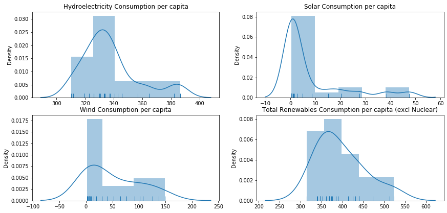

```python
hydro = data["('Hydroelectricity Consumption per Capita (toe/thousand Capita)', 'Total North America')"]
solar = data["('Solar Consumption per Capita (toe/thousand Capita)', 'Total North America')"]
wind = data["('Wind Consumption per Capita (toe/thousand Capita)', 'Total North America')"]
total = data["('Total Renewables Consumption per capita excluding Nuclear (toe/thousand capita)', 'Total North America')"]
oil_p = data["('Oil Price ($, value as of 2018)', 'Deflated using the Consumer Price Index for the US')"]
oil_c = data["('Oil Consumption per Capita (toe/thousand Capita)', 'Total North America')"]

fig = plt.figure(figsize = (14.4, 6.8))
plt.subplot(2, 2, 1)
ax = sns.distplot(hydro, rug=True, bins = 5)
ax.title.set_text('Hydroelectricity Consumption per capita')
ax.set_xlabel('')
ax.set_ylabel('Density')

plt.subplot(2, 2, 2)
ax = sns.distplot(solar, rug=True, bins = 5)
ax.title.set_text('Solar Consumption per capita')
ax.set_xlabel('')
ax.set_ylabel('Density')

plt.subplot(2, 2, 3)
ax = sns.distplot(wind, rug=True, bins = 5)
ax.title.set_text('Wind Consumption per capita')
ax.set_xlabel('')
ax.set_ylabel('Density')

plt.subplot(2, 2, 4)
ax = sns.distplot(total, rug=True, bins = 5)
ax.title.set_text('Total Renewables Consumption per capita (excl Nuclear)')
ax.set_xlabel('')
ax.set_ylabel('Density')

plt.show()
```

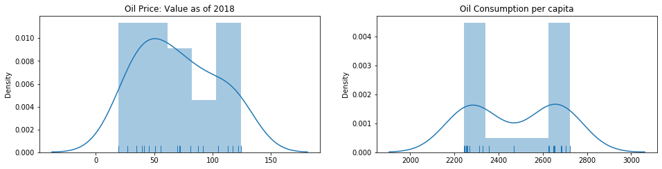

```python
fig = plt.figure(figsize = (16, 8))
plt.subplot(2, 2, 1)
ax = sns.distplot(oil_p, rug = True, bins = 5)
ax.title.set_text('Oil Price: Value as of 2018')
ax.set_xlabel('')
ax.set_ylabel('Density')

plt.subplot(2, 2, 2)
ax = sns.distplot(oil_c, rug = True, bins = 5)
ax.title.set_text('Oil Consumption per capita')
ax.set_xlabel('')
ax.set_ylabel('Density')
```

## Finding Median and Mean

Scroll down to the Median and Mean table to view the calculations in a more compact form than the code below.

```python
hydro.describe()
```

```
count     21.000000
mean     337.688669
std       20.339662
min      310.306620
25%      326.093276
50%      333.495251
75%      342.728862
max      386.643349
Name: ('Hydroelectricity Consumption per Capita (toe/thousand Capita)', 'Total North America'), dtype: float64
```

```python
hydro.median()
```

```
333.49525119842
```

```python
solar.describe()
```

```
count    21.000000
mean      8.181516
std      13.818332
min       0.298216
25%       0.342008
50%       0.852999
75%       8.485236
max      47.486059
Name: ('Solar Consumption per Capita (toe/thousand Capita)', 'Total North America'), dtype: float64
```

```python
solar.median()
```

```
0.852998765692171
```

```python
wind.describe()
```

```
count     21.000000
mean      50.276211
std       50.327043
min        1.766908
25%        6.403257
50%       30.292720
75%       92.179972
max      148.829200
Name: ('Wind Consumption per Capita (toe/thousand Capita)', 'Total North America'), dtype: float64
```

```python
wind.median()
```

```
30.29272034994053
```

```python
total.describe()
```

```
count     21.000000
mean     396.146397
std       57.267847
min      314.526597
25%      353.352906
50%      375.506428
75%      430.735689
max      523.181118
Name: ('Total Renewables Consumption per capita excluding Nuclear (toe/thousand capita)', 'Total North America'), dtype: float64
```

```python
total.median()
```

```
375.5064276587487
```

```python
oil_p.describe()
```

```
count     21.000000
mean      69.551712
std       33.069146
min       19.588906
25%       41.552885
50%       70.100498
75%       91.544764
max      124.198380
Name: ('Oil Price ($, value as of 2018)', 'Deflated using the Consumer Price Index for the US'), dtype: float64
```

```python
oil_p.median()
```

```
70.1004977962667
```

```python
oil_c.describe()
```

```
count      21.000000
mean     2471.524510
std       196.408924
min      2244.206422
25%      2260.247400
50%      2469.201393
75%      2652.277847
max      2721.656289
Name: ('Oil Consumption per Capita (toe/thousand Capita)', 'Total North America'), dtype: float64
```

```python
oil_c.median()
```

```
2469.201393287977
```

## Median and Mean Table

```python
avg_table = {'Name' : ['Hydroelectricity Consumption per Capita',
                     'Solar Consumption per Capita',
                     'Wind Consumption per Capita',
                     'Total Renewable Energy Consumption per Capita',
                     'Oil Price as of 2018',
                     'Oil Consumption per Capita'],
            'Mean' : [337, 8, 50, 396, 69, 2471],
            'Median' : [333, 0.85, 30, 375, 70, 2469]}
avg_t = pd.DataFrame.from_dict(avg_table)
avg_t
```

|  | Name | Mean | Median |
| --- | --- | --- | --- |
| 0 | Hydroelectricity Consumption per Capita | 337 | 333.00 |
| 1 | Solar Consumption per Capita | 8 | 0.85 |
| 2 | Wind Consumption per Capita | 50 | 30.00 |
| 3 | Total Renewable Energy Consumption per Capita | 396 | 375.00 |
| 4 | Oil Price as of 2018 | 69 | 70.00 |
| 5 | Oil Consumption per Capita | 2471 | 2469.00 |

## Quantile-Quantile Plot

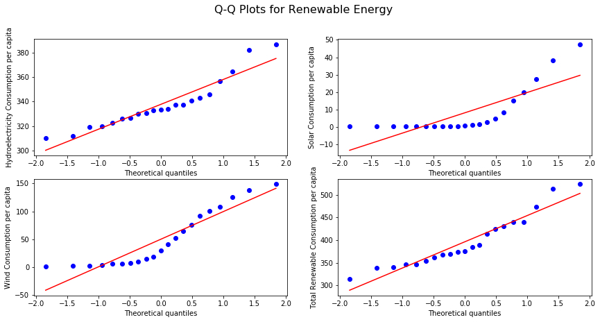

```python
import scipy.stats as stats

fig = plt.figure(figsize = (14.4, 6.8))
fig.suptitle('Q-Q Plots for Renewable Energy', fontsize=16)

plt.subplot(2, 2, 1)
ax = stats.probplot(hydro, dist="norm", plot=pylab)
plt.ylabel('Hydroelectricity Consumption per capita')
plt.title('')

plt.subplot(2, 2, 2)
ax = stats.probplot(solar, dist="norm", plot=pylab)
plt.ylabel('Solar Consumption per capita')
plt.title('')

plt.subplot(2, 2, 3)
ax = stats.probplot(wind, dist="norm", plot=pylab)
plt.ylabel('Wind Consumption per capita')
plt.title('')

plt.subplot(2, 2, 4)
ax = stats.probplot(total, dist="norm", plot=pylab)
plt.ylabel('Total Renewable Consumption per capita')
plt.title('')

pylab.show()
```

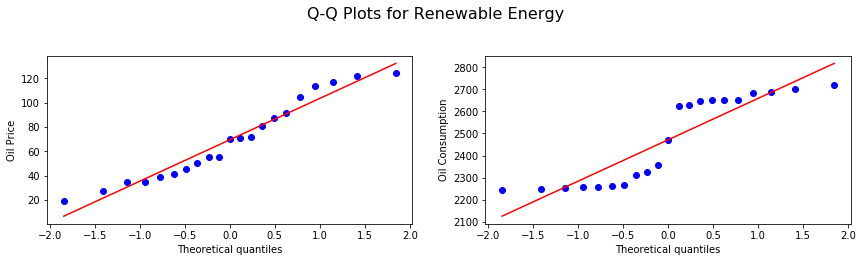

```python
fig = plt.figure(figsize = (14.4, 6.8))
fig.suptitle('Q-Q Plots for Renewable Energy', fontsize=16)

plt.subplot(2, 2, 1)
ax = stats.probplot(oil_p, dist="norm", plot=pylab)
plt.ylabel('Oil Price')
plt.title('')

plt.subplot(2, 2, 2)
ax = stats.probplot(oil_c, dist="norm", plot=pylab)
plt.ylabel('Oil Consumption')
plt.title('')
```

# Data Analysis

## Percentage of energy consumption by type of energy

The pie chart shows the percentages of energy consumption in North America. This illustrates that the energy market is predominantly nonrenewable energy sources. Oil, gas, and coal dominate the market.

## Linear Regressions & Correlations

We used a ordinary linear regression and plotted a correlation for:

1. Oil Price and Hydroelectricity Consumption
2. Oil Price and Solar Consumption
3. Oil Price and Wind Consumption
4. Oil Price and Total Renewable Energy Consumption

We wanted to see if the price of oil affected the renewable resources. A linear regression and correlation would show this relationship. This is important because oil is the leading enegy type consumed by North America. Also, we conducted a **Kendall tau** correlation test on solar energy consumption since it was not normally distributed. Kendall Rank Correlation assess statistical associations based on the ranks of the data. Kendall rank correlation (non-parametric) is an alternative to Pearson’s correlation (parametric) when the data you’re working with has failed one or more assumptions of the test.

None of our renewable variables appear to have a strong linear correlation with the price of oil. The orginial Solar data appears correlated in Kendall tau test,then we found the first half of Solar consumption is keeping increase but stay near zero. Then we test the second half of solar consumption, there are not correlated in Kendall tau test. This is good news for our investors. This means that one can invest in renewable energy without worry of the change of price of oil in long term(assuming our analysis is correct).

## What regions/countries are investmenting in renewable energies?

The time series plot of how much each region is investing in renewable resources. The second graph is a bar plot of renewable energy investment, per country, as a percentage of GDP. These graphs are two different ways to look at how the world, by region, then, by country, is investing in renewable resources. One important question any investor will ask is: "Is there room for growth in a market?" One should notice that United States appears to invest a large amount in renewable energy. However, looking at the second graph (renewable energy investment as a percentage of GDP), one will notice that the United States invest the least relative to the other countries. Therefore, the United States' renewable energy sector has much room to grow. A 2019 article on the website www.thebalance.com arrives at the same conclusion that the U.S. has much room for growth in the renewable energy sector.

## Solar Module Cost

Another reason to invest in renewable energy is because the cost of materials to produce renewable energy has decreased. Therefore, the return will be greater. Solar energy is an example of the lowering cost of renewable energy components. The cost of the photovaltaic modules has decreased and the modules today produce more energy per module than they did in the 1980's.

## Percentage of energy consumption by type of energy

```python
HydroelectricityConsumption=data.iloc[20:21,1]
NuclearConsumption=data.iloc[20:21,11]
SolarConsumption=data.iloc[20:21,21]
WindConsumption=data.iloc[20:21,31]
OtherrenewableConsumption=118.8-SolarConsumption-WindConsumption
OilConsumption=data.iloc[20:21,109]
CoalConsumption=343.3
GasConsumption=879.1
TotalConsumption=(HydroelectricityConsumption,NuclearConsumption,SolarConsumption,WindConsumption,OtherrenewableConsumption,OilConsumption,CoalConsumption,GasConsumption)

listpieNorthAmerica=[ 160.282466,217.944364,23.28534,72.980125,22.534535,1112.527817,343.3,879.1]
seriesOECD=pd.Series(listpieNorthAmerica,index=['Hydroelectricity','Nuclear','Solar','Wind','Other renewable','Oil Consumption','Coal Consumption','Gas Consumption'])
labels = ['Hydroelectricity','Nuclear','Solar','Wind','Other renewable','Oil Consumption','Coal Consumption','Gas Consumption']

fig = go.Figure(data=[go.Pie(labels=labels, values=listpieNorthAmerica)])
fig.update_layout(
    title="Energy Consumption in North America in 2018")

fig.show()
```

[interactive chart not shown]

## Time Series of Renewable Energy Consumption

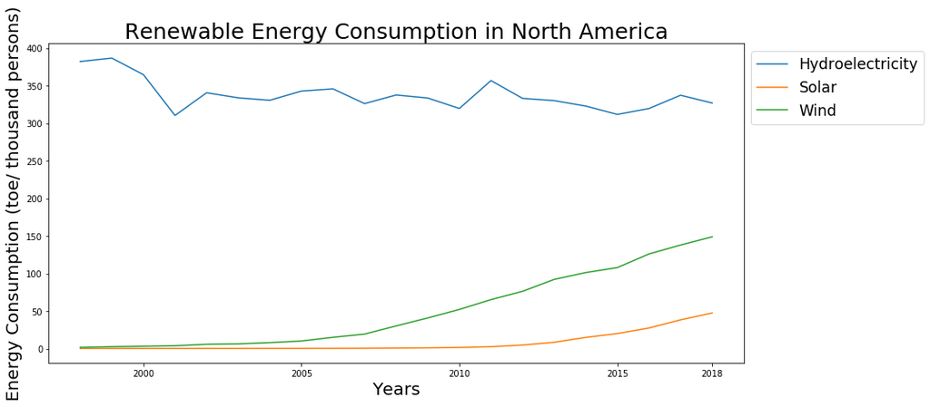

```python
x=data["Unnamed: 0"]
y1=data["('Hydroelectricity Consumption per Capita (toe/thousand Capita)', 'Total North America')"]
y2=data["('Solar Consumption per Capita (toe/thousand Capita)', 'Total North America')"]
y3=data["('Wind Consumption per Capita (toe/thousand Capita)', 'Total North America')"]

plt.figure(figsize = (14.4, 6.8))
plt.plot(x, y1, label = "Hydroelectricity")
plt.plot(x, y2, label = "Solar")
plt.plot(x, y3, label = "Wind")

plt.xticks([2000,2005,2010,2015,2018])
plt.title("Renewable Energy Consumption in North America", size = 25)
plt.xlabel("Years", size = 20)
plt.ylabel("Energy Consumption (toe/ thousand persons)", size = 20)
plt.legend(bbox_to_anchor = (1,1), fontsize = 'xx-large')
plt.show()
```

## Linear Regressions/ Correlations

### Hydroelectricity

```python
x = data["('Oil Price ($, value as of 2018)', 'Deflated using the Consumer Price Index for the US')"]
x1 = sm.add_constant(x)
y = data["('Hydroelectricity Consumption per Capita (toe/thousand Capita)', 'Total North America')"]

mod = sm.OLS(y, x1)
res = mod.fit()
res.summary()
```

OLS Regression Results

| Dep. Variable: | ('Hydroelectricity Consumption per Capita (toe/thousand Capita)', 'Total North America') | R-squared: | 0.079 |
| --- | --- | --- | --- |
| Model: | OLS | Adj. R-squared: | 0.030 |
| Method: | Least Squares | F-statistic: | 1.629 |
| Date: | Wed, 11 Dec 2019 | Prob (F-statistic): | 0.217 |
| Time: | 02:12:32 | Log-Likelihood: | -91.686 |
| No. Observations: | 21 | AIC: | 187.4 |
| Df Residuals: | 19 | BIC: | 189.5 |
| Df Model: | 1 |  |  |
| Covariance Type: | nonrobust |  |  |

|  | coef | std err | t | P>\|t\| | [0.025 | 0.975] |
| --- | --- | --- | --- | --- | --- | --- |
| const | 349.7094 | 10.383 | 33.680 | 0.000 | 327.977 | 371.442 |
| ('Oil Price ($, value as of 2018)', 'Deflated using the Consumer Price Index for the US') | -0.1728 | 0.135 | -1.276 | 0.217 | -0.456 | 0.111 |

| Omnibus: | 1.438 | Durbin-Watson: | 1.170 |
| --- | --- | --- | --- |
| Prob(Omnibus): | 0.487 | Jarque-Bera (JB): | 0.957 |
| Skew: | 0.514 | Prob(JB): | 0.620 |
| Kurtosis: | 2.811 | Cond. No. | 182. |

Warnings:  
[1] Standard Errors assume that the covariance matrix of the errors is correctly specified.

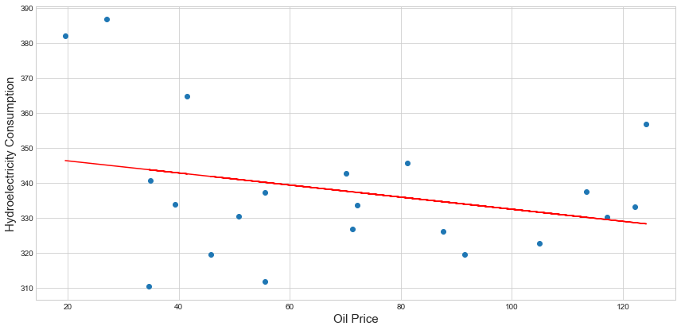

```python
stats = linregress(x, y)

m = stats.slope
b = stats.intercept

plt.figure(figsize = (14.4, 6.8))

plt.scatter(x, y)
plt.plot(x, m * x + b, color="red")
plt.xlabel("Oil Price", size = 15)
plt.ylabel("Hydroelectricity Consumption", size = 15)
plt.show()
```

```python
print('the slope is',m,'The y-intercept is',b)
```

```
the slope is -0.17283181963526684 The y-intercept is 349.7094184123002
```

### Nuclear Consumption

```python
y1 = data["('Nuclear Consumption per Capita (toe/thousand Capita)', 'Total North America')"]
mod = sm.OLS(y1, x1)
res = mod.fit()
res.summary()
```

OLS Regression Results

| Dep. Variable: | ('Nuclear Consumption per Capita (toe/thousand Capita)', 'Total North America') | R-squared: | 0.038 |
| --- | --- | --- | --- |
| Model: | OLS | Adj. R-squared: | -0.012 |
| Method: | Least Squares | F-statistic: | 0.7534 |
| Date: | Wed, 11 Dec 2019 | Prob (F-statistic): | 0.396 |
| Time: | 02:12:44 | Log-Likelihood: | -88.439 |
| No. Observations: | 21 | AIC: | 180.9 |
| Df Residuals: | 19 | BIC: | 183.0 |
| Df Model: | 1 |  |  |
| Covariance Type: | nonrobust |  |  |

|  | coef | std err | t | P>\|t\| | [0.025 | 0.975] |
| --- | --- | --- | --- | --- | --- | --- |
| const | 474.2944 | 8.896 | 53.317 | 0.000 | 455.675 | 492.914 |
| ('Oil Price ($, value as of 2018)', 'Deflated using the Consumer Price Index for the US') | -0.1007 | 0.116 | -0.868 | 0.396 | -0.344 | 0.142 |

| Omnibus: | 6.442 | Durbin-Watson: | 0.400 |
| --- | --- | --- | --- |
| Prob(Omnibus): | 0.040 | Jarque-Bera (JB): | 1.876 |
| Skew: | -0.219 | Prob(JB): | 0.391 |
| Kurtosis: | 1.603 | Cond. No. | 182. |

Warnings:  
[1] Standard Errors assume that the covariance matrix of the errors is correctly specified.

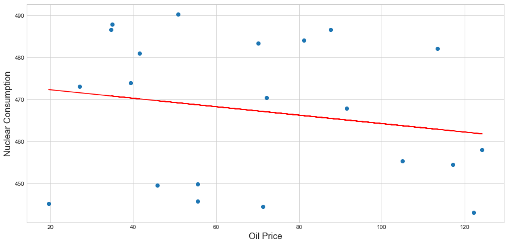

```python
stats = linregress(x, y1)

m = stats.slope
b = stats.intercept

plt.figure(figsize = (14.4, 6.8))

plt.scatter(x, y1)
plt.plot(x, m * x + b, color="red")
plt.xlabel("Oil Price", size = 15)
plt.ylabel("Nuclear Consumption", size = 15)
plt.show()
```

```python
print('The slope is',m,'The y-intercept is',b)
```

```
The slope is -0.10070501446681902 The y-intercept is 474.2944301892772
```

### Wind Consumption

```python
y2=data["('Wind Consumption per Capita (toe/thousand Capita)', 'Total North America')"]
mod = sm.OLS(y2, x1)
res = mod.fit()
res.summary()
```

OLS Regression Results

| Dep. Variable: | ('Wind Consumption per Capita (toe/thousand Capita)', 'Total North America') | R-squared: | 0.119 |
| --- | --- | --- | --- |
| Model: | OLS | Adj. R-squared: | 0.073 |
| Method: | Least Squares | F-statistic: | 2.578 |
| Date: | Wed, 11 Dec 2019 | Prob (F-statistic): | 0.125 |
| Time: | 02:12:51 | Log-Likelihood: | -110.24 |
| No. Observations: | 21 | AIC: | 224.5 |
| Df Residuals: | 19 | BIC: | 226.6 |
| Df Model: | 1 |  |  |
| Covariance Type: | nonrobust |  |  |

|  | coef | std err | t | P>\|t\| | [0.025 | 0.975] |
| --- | --- | --- | --- | --- | --- | --- |
| const | 13.6873 | 25.120 | 0.545 | 0.592 | -38.889 | 66.264 |
| ('Oil Price ($, value as of 2018)', 'Deflated using the Consumer Price Index for the US') | 0.5261 | 0.328 | 1.606 | 0.125 | -0.160 | 1.212 |

| Omnibus: | 5.644 | Durbin-Watson: | 0.081 |
| --- | --- | --- | --- |
| Prob(Omnibus): | 0.059 | Jarque-Bera (JB): | 4.586 |
| Skew: | 1.142 | Prob(JB): | 0.101 |
| Kurtosis: | 2.832 | Cond. No. | 182. |

Warnings:  
[1] Standard Errors assume that the covariance matrix of the errors is correctly specified.

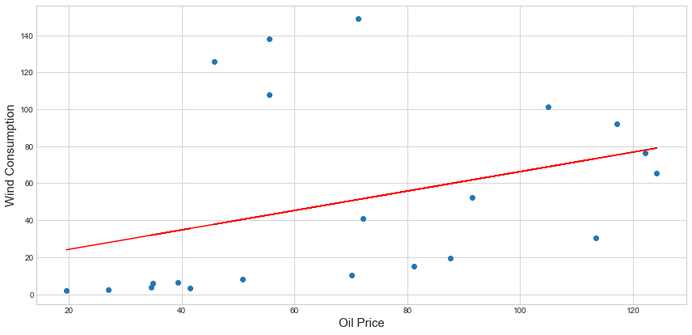

```python
stats = linregress(x, y2)

m = stats.slope
b = stats.intercept

plt.figure(figsize = (14.4, 6.8))

plt.scatter(x, y2)
plt.plot(x, m * x + b, color="red")
plt.xlabel("Oil Price", size = 15)
plt.ylabel("Wind Consumption", size = 15)
plt.show()
```

```python
print('The slope is',m,'The y-intercept is',b)
```

```
The slope is 0.5260682822198588 The y-intercept is 13.687261848589536
```

### Solar Consumption

```python
y3=data["('Solar Consumption per Capita (toe/thousand Capita)', 'Total North America')"]
mod = sm.OLS(y3, x1)
res = mod.fit()
res.summary()
```

OLS Regression Results

| Dep. Variable: | ('Solar Consumption per Capita (toe/thousand Capita)', 'Total North America') | R-squared: | 0.000 |
| --- | --- | --- | --- |
| Model: | OLS | Adj. R-squared: | -0.053 |
| Method: | Least Squares | F-statistic: | 0.0004253 |
| Date: | Wed, 11 Dec 2019 | Prob (F-statistic): | 0.984 |
| Time: | 02:12:57 | Log-Likelihood: | -84.431 |
| No. Observations: | 21 | AIC: | 172.9 |
| Df Residuals: | 19 | BIC: | 175.0 |
| Df Model: | 1 |  |  |
| Covariance Type: | nonrobust |  |  |

|  | coef | std err | t | P>\|t\| | [0.025 | 0.975] |
| --- | --- | --- | --- | --- | --- | --- |
| const | 8.3190 | 7.350 | 1.132 | 0.272 | -7.065 | 23.703 |
| ('Oil Price ($, value as of 2018)', 'Deflated using the Consumer Price Index for the US') | -0.0020 | 0.096 | -0.021 | 0.984 | -0.203 | 0.199 |

| Omnibus: | 15.411 | Durbin-Watson: | 0.090 |
| --- | --- | --- | --- |
| Prob(Omnibus): | 0.000 | Jarque-Bera (JB): | 14.269 |
| Skew: | 1.774 | Prob(JB): | 0.000797 |
| Kurtosis: | 4.929 | Cond. No. | 182. |

Warnings:  
[1] Standard Errors assume that the covariance matrix of the errors is correctly specified.

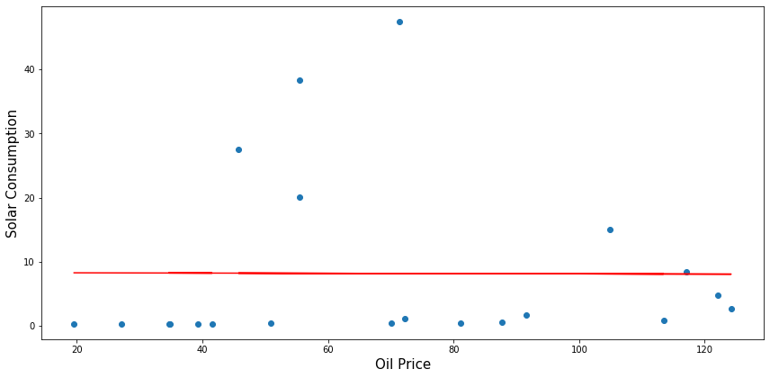

```python
stats = linregress(x, y3)

m = stats.slope
b = stats.intercept

plt.figure(figsize = (14.4, 6.8))

plt.scatter(x, y3)
plt.plot(x, m * x + b, color="red")
plt.xlabel("Oil Price", size = 15)
plt.ylabel("Solar Consumption", size = 15)
plt.show()
```

```python
print('The slope is',m,'The y-intercept is',b)
```

```
The slope is -0.0019770017543275643 The y-intercept is 8.319019798539275
```

```python
tau,p_value = stats.kendalltau(x,y3)
print('tau correlation coefficient: %.3f' % tau)
alpha = 0.05
if p_value > alpha:
	print('Samples are uncorrelated (fail to reject H0) p=%.3f' % p_value)
else:
	print('Samples are correlated (reject H0) p=%.3f' % p_value)
```

```
tau correlation coefficient: 0.448
Samples are correlated (reject H0) p=0.004
```

```python
y4=y3[11:21]
x2=x[11:21]
```

```python
tau,p_value = stats.kendalltau(x2,y4)
print('tau correlation coefficient: %.3f' % tau)
alpha = 0.05
if p_value > alpha:
	print('Samples are uncorrelated (fail to reject H0) p=%.3f' % p_value)
else:
	print('Samples are correlated (reject H0) p=%.3f' % p_value)
```

```
tau correlation coefficient: -0.378
Samples are uncorrelated (fail to reject H0) p=0.156
```

### Total Renewables

```python
y4 = data["('Total Renewables Consumption per capita excluding Nuclear (toe/thousand capita)', 'Total North America')"]
mod = sm.OLS(y4, x1)
res = mod.fit()
res.summary()
```

OLS Regression Results

| Dep. Variable: | ('Total Renewables Consumption per capita excluding Nuclear (toe/thousand capita)', 'Total North America') | R-squared: | 0.041 |
| --- | --- | --- | --- |
| Model: | OLS | Adj. R-squared: | -0.009 |
| Method: | Least Squares | F-statistic: | 0.8152 |
| Date: | Wed, 11 Dec 2019 | Prob (F-statistic): | 0.378 |
| Time: | 02:09:06 | Log-Likelihood: | -113.85 |
| No. Observations: | 21 | AIC: | 231.7 |
| Df Residuals: | 19 | BIC: | 233.8 |
| Df Model: | 1 |  |  |
| Covariance Type: | nonrobust |  |  |

|  | coef | std err | t | P>\|t\| | [0.025 | 0.975] |
| --- | --- | --- | --- | --- | --- | --- |
| const | 371.7157 | 29.829 | 12.462 | 0.000 | 309.283 | 434.148 |
| ('Oil Price ($, value as of 2018)', 'Deflated using the Consumer Price Index for the US') | 0.3513 | 0.389 | 0.903 | 0.378 | -0.463 | 1.166 |

| Omnibus: | 5.289 | Durbin-Watson: | 0.171 |
| --- | --- | --- | --- |
| Prob(Omnibus): | 0.071 | Jarque-Bera (JB): | 3.788 |
| Skew: | 1.037 | Prob(JB): | 0.150 |
| Kurtosis: | 3.156 | Cond. No. | 182. |

Warnings:  
[1] Standard Errors assume that the covariance matrix of the errors is correctly specified.

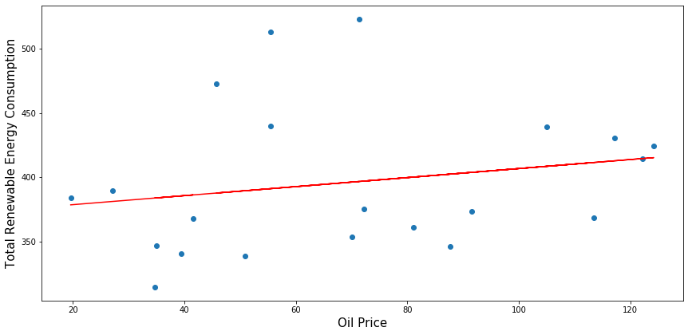

```python
stats = linregress(x, y4)

m = stats.slope
b = stats.intercept

plt.figure(figsize = (14.4, 6.8))

plt.scatter(x, y4)
plt.plot(x, m * x + b, color="red")
plt.xlabel("Oil Price", size = 15)
plt.ylabel("Total Renewable Energy Consumption", size = 15)
plt.show()
```

```python
print('The slope is',m,'The y-intercept is',b)
```

```
The slope is 0.35125946083026455 The y-intercept is 371.7157000594289
```

## What countries are investmenting in renewable energies?

```python
data=pd.read_excel('DATA_CLEAN_new.xlsx',sheet_name='Data')
data.head(3)
```

|  | Unnamed: 0 | ('Hydroelectricity Consumption (Mtoe)', 'Total North America') | ('Hydroelectricity Consumption (Mtoe)', 'Total S. & Cent. America') | ('Hydroelectricity Consumption (Mtoe)', 'Total Europe') | ('Hydroelectricity Consumption (Mtoe)', 'Total CIS') | ('Hydroelectricity Consumption (Mtoe)', 'Total Middle East') | ('Hydroelectricity Consumption (Mtoe)', 'Total Africa') | ('Hydroelectricity Consumption (Mtoe)', 'Total Asia Pacific') | ('Hydroelectricity Consumption (Mtoe)', 'Total World') | ('Hydroelectricity Consumption (Mtoe)', 'of which: OECD') | ... | ('CO2 emission', 'Total S. & Cent. America') | ('CO2 emission', 'Total Europe') | ('CO2 emission', 'Total CIS') | ('CO2 emission', 'Total Middle East') | ('CO2 emission', 'Total Africa') | ('CO2 emission', 'Total Asia Pacific') | ('CO2 emission', 'Total World') | ('CO2 emission', 'of which: OECD') | ('CO2 emission', 'Non-OECD') | Total World Population |
| --- | --- | --- | --- | --- | --- | --- | --- | --- | --- | --- | --- | --- | --- | --- | --- | --- | --- | --- | --- | --- | --- |
| 0 | 1998 | 153.313152 | 104.470335 | 127.773545 | 39.004966 | 3.102358 | 15.082339 | 111.235106 | 586.179017 | 305.668088 | ... | 771.293392 | 4735.554243 | 1787.743976 | 888.216871 | 735.783230 | 7063.424815 | 22792.783186 | 12604.162360 | 10188.620826 | 5954810550 |
| 1 | 1999 | 157.106911 | 105.018872 | 128.244899 | 39.337495 | 1.976524 | 15.994085 | 109.319706 | 590.193126 | 307.727990 | ... | 762.344102 | 4688.402608 | 1787.361476 | 902.873264 | 754.917923 | 7370.890141 | 23115.503513 | 12713.221745 | 10402.281768 | 6035284135 |
| 2 | 2000 | 149.929019 | 110.959071 | 133.413733 | 40.515013 | 1.585866 | 17.026252 | 113.790855 | 600.693195 | 309.271324 | ... | 770.806588 | 4707.617065 | 1778.378949 | 951.833482 | 764.048531 | 7605.861318 | 23667.608967 | 13006.283738 | 10661.325229 | 6115108363 |

3 rows × 140 columns

### Investing in Renewable Energy

```python
invest = pd.read_csv('renewable-energy-investment.csv')
invest_gdp = pd.read_csv('renewable-energy-investment-of-gdp.csv')
invest_gdp.head()
```

|  | Entity | Code | Year | (% of GDP) |
| --- | --- | --- | --- | --- |
| 0 | Brazil | BRA | 2015 | 0.4 |
| 1 | Chile | CHL | 2015 | 1.4 |
| 2 | China | CHN | 2015 | 0.9 |
| 3 | Germany | DEU | 2015 | 0.3 |
| 4 | India | IND | 2015 | 0.5 |

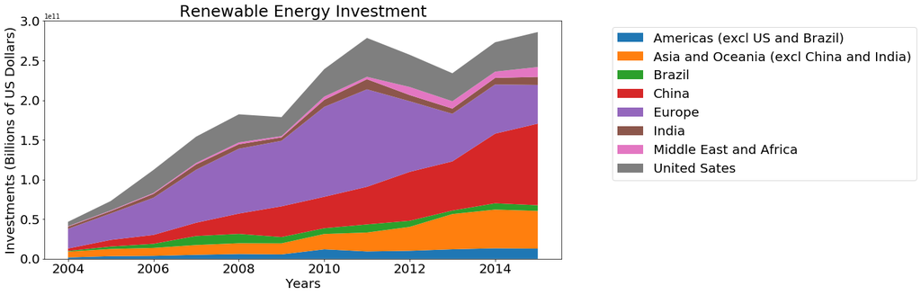

```python
plt.figure(figsize = (14.4, 6.8))
x = invest['Year'][0:12]
y1 = [invest['Investment in Renewables by Region (IRENA (2016)) (international-$)'][0:12],
    invest['Investment in Renewables by Region (IRENA (2016)) (international-$)'][12:24],
    invest['Investment in Renewables by Region (IRENA (2016)) (international-$)'][24:36],
    invest['Investment in Renewables by Region (IRENA (2016)) (international-$)'][36:48],
    invest['Investment in Renewables by Region (IRENA (2016)) (international-$)'][48:60],
    invest['Investment in Renewables by Region (IRENA (2016)) (international-$)'][60:72],
    invest['Investment in Renewables by Region (IRENA (2016)) (international-$)'][72:84],
    invest['Investment in Renewables by Region (IRENA (2016)) (international-$)'][84:96]]
plt.stackplot(x, y1, labels=['Americas (excl US and Brazil)','Asia and Oceania (excl China and India)','Brazil','China','Europe','India','Middle East and Africa', 'United Sates'])
plt.legend(bbox_to_anchor = (1.70, 1), prop={'size': 20})
plt.title("Renewable Energy Investment", size = 25)
plt.xlabel("Years", size = 20)
plt.ylabel("Investments (Billions of US Dollars)", size = 20)
plt.xticks(size = 20)
plt.yticks(size = 20)
plt.show()

# Investment in renewable energy technologies per year in billion US dollars by region.
```

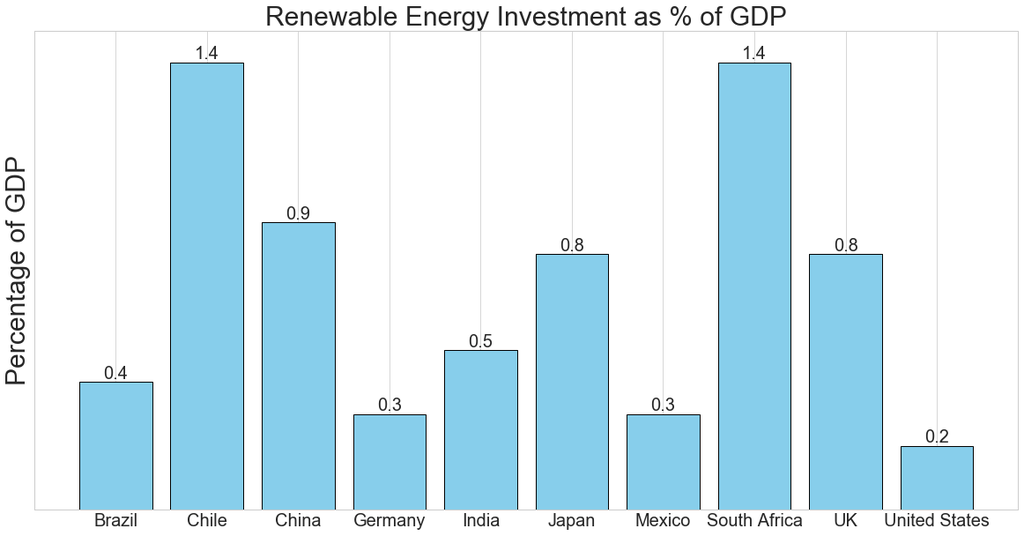

```python
# Investment in renewable energy,
# given as the percentage of each nation's gross domestic product (GDP) in 2015
plt.style.use('seaborn-whitegrid')

x = [0, 1, 2, 3, 4, 5, 6, 7, 8, 9]
width = 0.8 # width of the bars
fig = plt.figure(figsize = (20,30))
fig, ax = plt.subplots(figsize = (20, 10))
rects1 = ax.bar(invest_gdp['Entity'], invest_gdp[' (% of GDP)'], width, color='skyblue', edgecolor = 'black')

ax.set_ylim(0,1.5)
ax.set_ylabel('Percentage of GDP', size = 30)
ax.set_title('Renewable Energy Investment as % of GDP', size = 30)
ax.set_xticks(x) # set the position of the x ticks
ax.set_yticks([])
ax.tick_params(axis="x", labelsize=20)
ax.tick_params(axis="y", labelsize=20)

def autolabel(rects):
    # attach some text labels
    for rect in rects:
        height = rect.get_height()
        ax.text(rect.get_x() + rect.get_width()/2., height,
                height,
                ha='center', va='bottom', size = 20)

autolabel(rects1)

plt.show()
```

### Solar Module Cost

```python
solar = pd.read_csv('solar-pv-prices-vs-cumulative-capacity.csv')
solar.columns
```

```
Index(['Entity', 'Code', 'Year',
       'Solar PV Module Cost (2016 $ per watt-peak (2016 $/Wp))',
       'Cumulative Installed Capacity (megawatts-peak (MWp))',
       'Total population (Gapminder)'],
      dtype='object')
```

```python
fig = go.Figure()
fig.add_trace(go.Scatter(
    x = solar['Cumulative Installed Capacity (megawatts-peak (MWp))'],
    y = solar['Solar PV Module Cost (2016 $ per watt-peak (2016 $/Wp))']
))
fig.add_annotation(
    go.layout.Annotation(
            x=0.81756,
            y=1.37576,
            text="1980"))
fig.add_annotation(
    go.layout.Annotation(
            x=1.85107,
            y=1.09671,
            text="1985"))
fig.add_annotation(
    go.layout.Annotation(
            x=2.35977,
            y=1.00042,
            text="1990"))
fig.add_annotation(
    go.layout.Annotation(
            x=2.71556,
            y=0.84943,
            text="1995"))
fig.add_annotation(
    go.layout.Annotation(
            x=3.10669,
            y=0.56229,
            text="2000"))
fig.add_annotation(
    go.layout.Annotation(
            x=3.72173,
            y=0.55390,
            text="2005"))
fig.add_annotation(
    go.layout.Annotation(
            x=4.61417,
            y=0.20116,
            text="2010"))
fig.add_annotation(
    go.layout.Annotation(
            x=5.09542,
            y=-0.08444,
            text="2013"))
fig.update_layout(
title={
        'text': "Solar PV module prices vs. cumulative capacity, 1976 to 2016",
        'y':0.9,
        'x':0.5,
        'xanchor': 'center',
        'yanchor': 'top'}, xaxis_type="log", yaxis_type="log",
xaxis = dict(
tickmode = 'linear', title ="Cumulative Installed Capacity (megawatts-peak)"),
yaxis = dict(
tickmode = 'linear', title = 'Solar PV Module Cost (US Dollars per watt-peak)'))
fig.update_annotations(dict(
            xref="x",
            yref="y",
            showarrow=True,
            arrowhead=7,
            ax=0,
            ay=-40
))
fig.show()
```

[interactive chart not shown]

# Conclusion

When deciding which companies to invest in, investors look at the trends as well as profitability in that sector.

# References

[Kernal Density Estimation](https://jakevdp.github.io/PythonDataScienceHandbook/05.13-kernel-density-estimation.html)

[Per Capita](https://www.thebalance.com/per-capita-what-it-means-calculation-how-to-use-it-3305876)

[Histograms](https://asq.org/quality-resources/histogram)

[More on Histograms](https://machinelearningmastery.com/a-gentle-introduction-to-normality-tests-in-python/)

[Q-Q Plots](https://stackoverflow.com/questions/13865596/quantile-quantile-plot-using-scipy)

[Statistics](https://docs.scipy.org/doc/scipy-0.14.0/reference/generated/scipy.stats.probplot.html)

[Kendal-Tau 1](https://docs.scipy.org/doc/scipy-0.15.1/reference/generated/scipy.stats.kendalltau.html)

[Kendal-Tau 2](https://www.statisticssolutions.com/kendalls-tau-and-spearmans-rank-correlation-coefficient/)

[Kendal-Tau 3](https://towardsdatascience.com/kendall-rank-correlation-explained-dee01d99c535)

[Investing in Renewables 1](https://www.thebalance.com/how-to-invest-in-the-global-renewable-energy-sector-4056875)

[Investing in Renewables 2](https://www.greentechmedia.com/articles/read/where-renewables-capital-will-come-from)

[Investing in Renewables in U.S.](https://www.thebalance.com/renewable-energy-industry-current-state-trends-outlook-4684187)

[EIA](https://www.eia.gov/totalenergy/data/monthly/)

[Most Popular Renewables](https://www.thebalancesmb.com/what-are-the-most-popular-forms-of-clean-energy-4172965)

[Renewable Energy](https://ourworldindata.org/renewable-energy)